# Analysis of experiment data

Sidhu, Woodin, Perlman, Winter

2026-04-06

# 1 Introduction

This script presents an analysis of the experimental data. First descriptive statistics and visualizations for both, then Bayesian models.

Load libraries:

```r
library(tidyverse)
library(brms)
```

Load data:

```r
E1 <- read_csv('../data/E1_processed.csv')
E2 <- read_csv('../data/E2_processed.csv')

# Show:

sample_n(E1, 10)
```

```
## # A tibble: 10 × 9
##    participant word       word_class  icon   rt_z icon_z quantile    rt   acc
##          <dbl> <chr>      <chr>      <dbl>  <dbl>  <dbl>    <dbl> <dbl> <dbl>
##  1          16 katsukatsu Mim        1.33  -0.565 -0.657        2 1.26      0
##  2          43 matsuri    Noun       2      0.142  0.156        3 2.56      1
##  3          39 nukeru     Verb       1.69  -0.808 -0.225        3 0.817     1
##  4         113 kagiri     Noun       1.64  -0.448 -0.280        3 1.48      0
##  5          64 mijikana   Adj        0.833  1.83  -1.27         1 5.66      1
##  6           1 burari     Mim        2.15  -0.195  0.343        4 1.94      0
##  7           7 mamoru     Verb       2.71  -0.315  1.03         5 1.72      1
##  8          64 hitotsu    Noun       2.23   0.918  0.437        4 3.99      0
##  9          32 samui      Adj        2.77   0.241  1.09         5 2.74      0
## 10         119 hiyohiyo   Mim        1      0.647 -1.06         1 3.49      1
```

```r
sample_n(E2, 10)
```

```
## # A tibble: 10 × 9
##    participant word       word_class  icon    rt_z icon_z quantile    rt   acc
##          <dbl> <chr>      <chr>      <dbl>   <dbl>  <dbl>    <dbl> <dbl> <dbl>
##  1          32 hiku       Verb        2.35 -0.320   0.596        4 1.22      0
##  2          55 machigau   Verb        1.2  -0.628  -0.821        2 0.467     0
##  3          41 hanashi    Noun        1.05 -0.0783 -1.01         1 1.81      0
##  4          49 hiyohiyo   Mim         1    -0.0606 -1.07         1 1.85      1
##  5          34 hitoshii   Adj         1.21  0.556  -0.803        2 3.35      1
##  6          21 katsukatsu Mim         1.33  1.23   -0.657        2 4.99      0
##  7          65 hiratai    Adj         2.91 -0.447   1.28         5 0.910     0
##  8         131 matsuri    Noun        2    -0.0401  0.162        3 1.90      1
##  9          80 tegami     Noun        0.3   0.0648 -1.93         1 2.15      0
## 10          84 nemui      Adj         3.58 -0.163   2.11         5 1.60      1
```

Load item data as well:

```r
items <- read_csv('../data/item_properties.csv')

colnames(items) <- str_to_lower(colnames(items))
```

We’ll use this as the standard fill color again:

```r
default_col <- 'darkorchid4'
```

# 2 Merge files

For easier processing, we’ll merge both into the same file separate by form-to-meaning (E1) and meaning-to-form (E2) matching.

```r
both <- bind_rows(E1, E2)

# Task identifier:

both$experiment <- c(rep('form-to-meaning (E1)', nrow(E1)),
                     rep('meaning-to-form (E2)', nrow(E2)))
```

# 3 Descriptive statistics

## 3.1 Average rt

Check the average RT per experiment:

```r
both |>
  group_by(experiment) |>
  summarize(rt_mean = mean(rt))
```

```
## # A tibble: 2 × 2
##   experiment           rt_mean
##   <chr>                  <dbl>
## 1 form-to-meaning (E1)    2.30
## 2 meaning-to-form (E2)    2.00
```

They took about 2 seconds to respond.

## 3.2 Overall accuracy (grand mean)

First, what’s the overall accuracy?

```r
both |>
  group_by(experiment) |>
  summarize(acc_mean = mean(acc))
```

```
## # A tibble: 2 × 2
##   experiment           acc_mean
##   <chr>                   <dbl>
## 1 form-to-meaning (E1)    0.530
## 2 meaning-to-form (E2)    0.535
```

## 3.3 Variation by participants

Check the mean accuracy of participants. First, create a tibble of the participant averages:

```r
acc_ppt_avgs <- both |>
  group_by(experiment, participant) |>
  summarize(acc_mean = mean(acc)) |>
  ungroup(experiment)
```

What are the lowest and highest participant accuracy per experiment?

```r
acc_ppt_avgs |>
  group_by(experiment) |>
  filter(acc_mean %in% range(acc_mean))
```

```
## # A tibble: 7 × 3
## # Groups:   experiment [2]
##   experiment           participant acc_mean
##   <chr>                      <dbl>    <dbl>
## 1 form-to-meaning (E1)          66    0.333
## 2 form-to-meaning (E1)         101    0.75
## 3 meaning-to-form (E2)          17    0.729
## 4 meaning-to-form (E2)          24    0.396
## 5 meaning-to-form (E2)          41    0.396
## 6 meaning-to-form (E2)          62    0.396
## 7 meaning-to-form (E2)         129    0.396
```

The highest accuracy any participant achieved in experiment 1 was 75%, the lowest was 33%.

In experiment 2, the highest accuracy was 72.9%, and 4 participant shared the spot of the lowest accuracy with 39.6%.

Save these means for plotting:

```r
E1_mean <- mean(E1$acc)
E2_mean <- mean(E2$acc)

# In tibble:

both_means <- both |>
  group_by(experiment) |>
  summarize(acc_mean = mean(acc))
```

Plot the distribution of this:

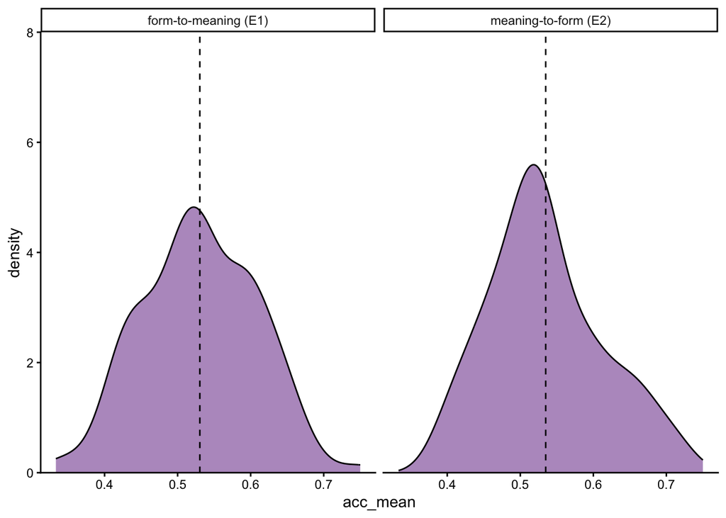

```r
acc_ppt_avgs |>
  ggplot(aes(x = acc_mean)) +
  geom_density(fill = default_col, alpha = 0.5) +
  geom_vline(data = both_means,
             mapping = aes(xintercept = acc_mean),
             linetype = 'dashed') +
  scale_y_continuous(expand = c(0, 0),
                     limits = c(0, 8)) +
  facet_wrap(~experiment) +
  theme_classic()
```

## 3.4 Variation by items

Create tibble that contains mean accuracy by items:

```r
acc_item_avgs <- both |>
  group_by(experiment, word, word_class, icon) |>
  summarize(acc_mean = mean(acc)) |>
  ungroup(experiment)
```

What are the lowest and highest item accuracy per experiment?

```r
acc_item_avgs |>
  group_by(experiment) |>
  filter(acc_mean %in% range(acc_mean))
```

```
## # A tibble: 4 × 5
## # Groups:   experiment [2]
##   experiment           word     word_class  icon acc_mean
##   <chr>                <chr>    <chr>      <dbl>    <dbl>
## 1 form-to-meaning (E1) garan    Mim        1.75     0.784
## 2 form-to-meaning (E1) hitotsu  Noun       2.23     0.193
## 3 meaning-to-form (E2) mijikana Adj        0.833    0.314
## 4 meaning-to-form (E2) moji     Noun       2.64     0.711
```

The highest accuracy was the ideophone “garan” in Experiment 1, and the noun “moji” in Experiment 2.

Plot the distribution of this:

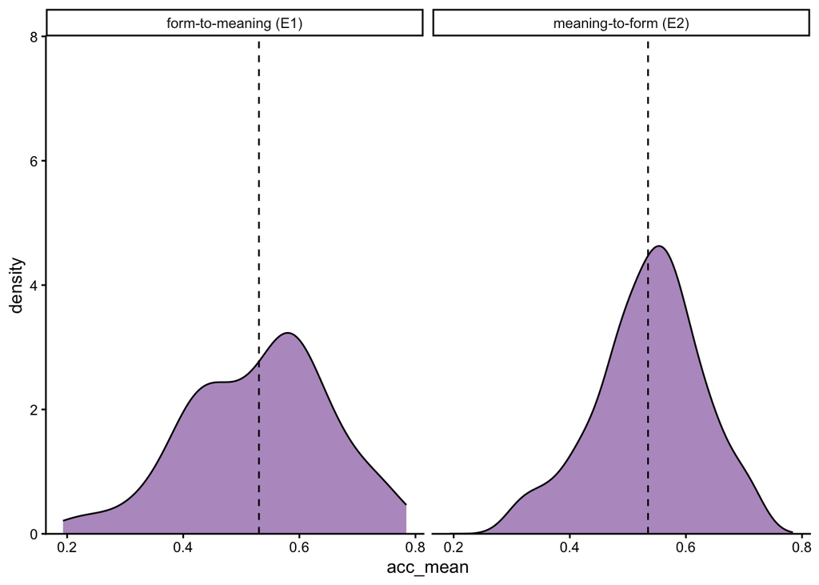

```r
acc_item_avgs |>
  ggplot(aes(x = acc_mean)) +
  geom_density(fill = default_col, alpha = 0.5) +
  geom_vline(data = both_means,
             mapping = aes(xintercept = acc_mean),
             linetype = 'dashed') +
  scale_y_continuous(expand = c(0, 0),
                     limits = c(0, 8)) +
  facet_wrap(~experiment) +
  theme_classic()
```

## 3.5 Word class

Check descriptive accuracy by word class:

```r
both |>
  group_by(experiment, word_class) |>
  summarize(acc_mean = mean(acc))
```

```
## # A tibble: 8 × 3
## # Groups:   experiment [2]
##   experiment           word_class acc_mean
##   <chr>                <chr>         <dbl>
## 1 form-to-meaning (E1) Adj           0.535
## 2 form-to-meaning (E1) Mim           0.510
## 3 form-to-meaning (E1) Noun          0.538
## 4 form-to-meaning (E1) Verb          0.538
## 5 meaning-to-form (E2) Adj           0.518
## 6 meaning-to-form (E2) Mim           0.544
## 7 meaning-to-form (E2) Noun          0.535
## 8 meaning-to-form (E2) Verb          0.543
```

## 3.6 Iconicity

First, let’s check average accuracy by iconicity quantile:

```r
both |>
  group_by(experiment, quantile) |>
  summarize(acc_mean = mean(acc))
```

```
## # A tibble: 10 × 3
## # Groups:   experiment [2]
##    experiment           quantile acc_mean
##    <chr>                   <dbl>    <dbl>
##  1 form-to-meaning (E1)        1    0.586
##  2 form-to-meaning (E1)        2    0.526
##  3 form-to-meaning (E1)        3    0.498
##  4 form-to-meaning (E1)        4    0.539
##  5 form-to-meaning (E1)        5    0.505
##  6 meaning-to-form (E2)        1    0.530
##  7 meaning-to-form (E2)        2    0.519
##  8 meaning-to-form (E2)        3    0.527
##  9 meaning-to-form (E2)        4    0.543
## 10 meaning-to-form (E2)        5    0.556
```

No consistent relationship.

Second, check descriptive correlations between average iconicity and average accuracy on a by-item level:

```r
with(filter(acc_item_avgs, experiment == 'form-to-meaning (E1)'),
     cor.test(icon, acc_mean))
```

```
##
##  Pearson's product-moment correlation
##
## data:  icon and acc_mean
## t = -1.3946, df = 98, p-value = 0.1663
## alternative hypothesis: true correlation is not equal to 0
## 95 percent confidence interval:
##  -0.32695642  0.05852487
## sample estimates:
##        cor
## -0.1394968
```

```r
with(filter(acc_item_avgs, experiment == 'meaning-to-form (E2)'),
     cor.test(icon, acc_mean))
```

```
##
##  Pearson's product-moment correlation
##
## data:  icon and acc_mean
## t = 1.6359, df = 98, p-value = 0.1051
## alternative hypothesis: true correlation is not equal to 0
## 95 percent confidence interval:
##  -0.0344863  0.3483006
## sample estimates:
##       cor
## 0.1630362
```

Average correlation across both experiments:

```r
acc_item_avgs_both <- both |>
  group_by(word, icon) |>
  summarize(acc_mean = mean(acc))
with(acc_item_avgs_both,
     cor.test(icon, acc_mean))
```

```
##
##  Pearson's product-moment correlation
##
## data:  icon and acc_mean
## t = -0.10288, df = 98, p-value = 0.9183
## alternative hypothesis: true correlation is not equal to 0
## 95 percent confidence interval:
##  -0.2063884  0.1864070
## sample estimates:
##         cor
## -0.01039159
```

Plot these correlations with quick-and-dirty frequentist linear model lines:

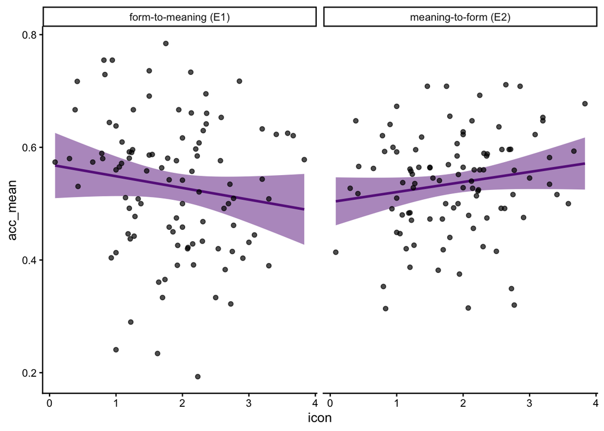

```r
acc_item_avgs |>
  ggplot(aes(x = icon, y = acc_mean)) +
  geom_smooth(col = default_col,
              fill = default_col,
              alpha = 0.5,
              method = 'lm') +
  geom_point(alpha = 0.7) +
  facet_wrap(~experiment) +
  theme_classic()
```

# 4 Models

## 4.1 Prior specification

Due to the high similarity of both experiments, we can use the same priors for both.

Previously, David used a `normal(0, 0.5)` for the intercept, and a `cauchy(0, 2.5)` prior for the slope, the latter in line with the recommendations for sensible logistic regression default weakly informative priors from the Gelman et al. (2008).

Following the more precise prior reasoning in the meta-analysis, and also for comparability with the meta-analysis, we want to fit better, and more theoretically motivated priors than just that. It also is the case that the intercept prior is very wide:

```r
plogis(-0.5);plogis(+0.5)   # 68% of all plausible intercepts
```

```
## [1] 0.3775407
```

```
## [1] 0.6224593
```

```r
plogis(-1);plogis(+1)       # 95% of all plausible intercepts
```

```
## [1] 0.2689414
```

```
## [1] 0.7310586
```

The prior motivation for the meta-analysis was done for the phonetic symbolism literature, which largely used antonyms. In this study, we also include ideophones. This, however, makes little difference: after all, Dingemanse et al. (2016) found the force-choice guessability of ideophones to be *at most* ~57% on average…

… so assuming an intercept focused on 50% with the same sigma that we determined for the meta-analysis is fully appropriate here. This intercept would be open with the accuracy to be as high as in the Dingemanse et al. study that only included ideophones; given that we also have 3/4 of the data being non-ideophones, we don’t expect the average across the experiment to be that high, so the slightly lower probability mass of the meta-analysis prior for the intercept for ~60% is appropriate.

Another approach would be to use the average resulting from the meta-analysis as prior for the experiments. We’ll perform that analysis too, but only after the more agnostic prior that’s focused on 50% accuracy, as otherwise one could accuse us of cheating.

So again, let’s find the sigma value that’s 40%/60% accuracy for the 95% interval of a t-distribution with degrees of freedom = 3.

```r
sigma <- qlogis(0.6) / qt(0.975, df = 3)

# Show:

sigma
```

```
## [1] 0.1274067
```

The iconicity ratings come from Thompson et al. (2020), who used a -5 to +5 iconicity rating scale following Perry et al. (2015). As is often the case using such a scale and the nominal fit heuristic exposed by Sutherland and Cimpian (2015), participants mostly used the positive end of the scale. This is also because the concept of non-arbitrariness is ill-defined, see also Motamedi et al. (2019) and Winter et al. (2023).

Here’s a look at the actual item properties in terms of iconicity for both the standardized and non-standardized:

```r
# Raw scale:

range(both$icon)
```

```
## [1] 0.08333333 3.83333333
```

```r
# Standardized scale:

range(both$icon_z)
```

```
## [1] -2.192793  2.414569
```

Let’s briefly visualize the iconicity ratings across items on the standardized scale to get an idea of the spread of this variable. Since the items are the same across experiments we need to only use one experiment:

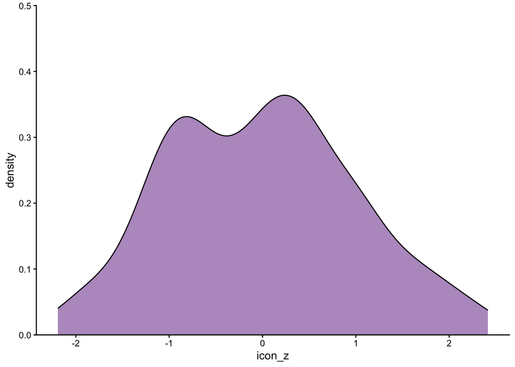

```r
both |>
  distinct(word, icon, icon_z) |>
  ggplot(aes(x = icon_z)) +
  geom_density(fill = default_col, alpha = 0.5) +
  scale_y_continuous(expand = c(0, 0),
                     limits = c(0, 0.5)) +
  theme_classic()
```

All else being equal, it would seem that if iconicity increased by one standard deviation, and accuracy increased by 10%, that would be a big effect of iconicity - for a fully-fledged language with conventional words that have already undergone de-iconicization.

Now, for word class, we can use the difference between the phonetic symbolism experiments and Dingemanse et al. (2016) as a good baseline. The latter has ideophones and the average is at most 57%. To allow for possibly slightly more accurate ideophones, we’ll say that the 95% range is set to 60%. If there’s a lot of evidence in the data for the ideophone coefficient to be high, we could still find that effect (our sample size is decent), but all else being equal we’re skeptical of effects *that* high.

So, in this rare case, it actually makes sense to specify the same sigma for *both* the continuous and the categorical beta slope, since our expectations for 1 unit change (continuous) or pairwise differences (categorical) are similar.

The standard deviations will be a bit more tricky. After a bit of experimenting with different values, I arrived at SD = 0.25 for item random effect SD, and SD = 0.1 for participant random effect SD.

The item effect SD of 0.25 corresponds to saying that a 95% upper bound of the SD value would be:

```r
item_sd_upper <- qt(0.975, df = 3) * 0.25

item_sd_upper
```

```
## [1] 0.7956116
```

… which applying that to the raw probability scale suggests that 95% of all items would lie between:

```r
plogis(c(-1.96 * item_sd_upper, 1.96 * item_sd_upper))
```

```
## [1] 0.1737329 0.8262671
```

And that seems very sensible. It’s quite agnostic but open to *some few* items still being as accurate as 80%. The actual SD is likely going to be lower given that these are mostly conventional words that cannot be guessed easily and we expect the range of item variation to be quite constrained closer to 50%, but I don’t want to induce too much shrinkage to artificially bias uncertainty downwards.

Another way of thinking this is that Cwiek et al. (2021) obtained an item SD of 1.12, which is higher than what I propose here, but that study was conducted on raw iconic vocalizations rather than conventionalized words. So 0.8 seems like a decent value given this other study as well.

Then for participant sd, I’ll choose a smaller value, as we have found in Cwiek et al. (2021) that item SD > participant SD. 0.10 seems like a nice round number that implies the following:

```r
ppt_sd_upper <- qt(0.975, df = 3) * 0.1

ppt_sd_upper  # SD value
```

```
## [1] 0.3182446
```

```r
plogis(c(-1.96 * ppt_sd_upper, 1.96 * ppt_sd_upper)) # 95% of all participants fall within
```

```
## [1] 0.3489269 0.6510731
```

This seems sensible. It would be quite unexpected if participants with no knowledge of Japanese all of a sudden could guess words much better than that.

For the random effects correlation, we use the standard LKJ-2 distribution.

So all together:

With all of this in mind, let’s use these priors:

```r
exp_priors <- c(prior(student_t(3, 0, 0.1274067), class = 'Intercept'),
                prior(student_t(3, 0, 0.1274067), class = 'b'), # same for continuous and categorical makes sense in this specific case
                prior(student_t(3, 0, 0.25), class = 'sd', group = 'word'),
                prior(student_t(3, 0, 0.1), class = 'sd', group = 'participant'), # covers both intercept and slope, similar expectation (see above)
                prior(lkj(2), class = 'cor'))
```

Check that we’ve covered all:

```r
get_prior(acc ~ 1 + icon_z + word_class +
            (1 + icon_z + word_class|participant) +
            (1|word),
          data = E1,
          family = bernoulli(link = 'logit'))
```

```
##                 prior     class           coef       group resp dpar nlpar lb
##                (flat)         b
##                (flat)         b         icon_z
##                (flat)         b  word_classMim
##                (flat)         b word_classNoun
##                (flat)         b word_classVerb
##                lkj(1)       cor
##                lkj(1)       cor                participant
##  student_t(3, 0, 2.5) Intercept
##  student_t(3, 0, 2.5)        sd                                             0
##  student_t(3, 0, 2.5)        sd                participant                  0
##  student_t(3, 0, 2.5)        sd         icon_z participant                  0
##  student_t(3, 0, 2.5)        sd      Intercept participant                  0
##  student_t(3, 0, 2.5)        sd  word_classMim participant                  0
##  student_t(3, 0, 2.5)        sd word_classNoun participant                  0
##  student_t(3, 0, 2.5)        sd word_classVerb participant                  0
##  student_t(3, 0, 2.5)        sd                       word                  0
##  student_t(3, 0, 2.5)        sd      Intercept        word                  0
##  ub tag       source
##              default
##         (vectorized)
##         (vectorized)
##         (vectorized)
##         (vectorized)
##              default
##         (vectorized)
##              default
##              default
##         (vectorized)
##         (vectorized)
##         (vectorized)
##         (vectorized)
##         (vectorized)
##         (vectorized)
##         (vectorized)
##         (vectorized)
```

We don’t need to specify separate `word_classMim` etc. random slopes since our expectations for intercept and slope are similar, logit SD = `0.1` each.

## 4.2 Reference level

We’ll use `Noun` as the reference level as prior research suggest that this should be lowest in iconicity (e.g., Perry et al. 2015, Winter et al. 2017). Then all coefficients are deviations from that lowest level, i.e., adjective v noun, verbs v noun and ideophones v noun.

```r
E1 <- mutate(E1,
             word_class = factor(word_class),
             word_class = relevel(word_class, ref = 'Noun'))

E2 <- mutate(E2,
             word_class = factor(word_class),
             word_class = relevel(word_class, ref = 'Noun'))

both <- mutate(both,
               word_class = factor(word_class),
               word_class = relevel(word_class, ref = 'Noun'))
```

## 4.3 Experiment 1

### 4.3.1 Fit models

Fit the model. First, separate for each experiment. Experiment 1:

```r
E1_mdl <- brm(acc ~ 1 + icon_z + word_class +
                (1 + icon_z + word_class|participant) +
                (1|word),
              data = E1,
              prior = exp_priors,
              family = bernoulli(link = 'logit'),

              # MCMC settings:

              save_pars = save_pars(all = TRUE),
              cores = 4, chains = 4,
              warmup = 4000, iter = 16000, thin = 1, # 48k for stable bayes factors
              seed = 42)

# No iconicity null model

E1_no_icon_mdl <- brm(acc ~ 1 + word_class +
                (1 + icon_z + word_class|participant) +
                (1|word),
              data = E1,
              prior = exp_priors,
              family = bernoulli(link = 'logit'),

              # MCMC settings:

              save_pars = save_pars(all = TRUE),
              cores = 4, chains = 4,
              warmup = 4000, iter = 16000, thin = 1,
              seed = 42)

# No word class null model:

E1_no_word_class_mdl <- brm(acc ~ 1 + icon_z +
                (1 + icon_z + word_class|participant) +
                (1|word),
              data = E1,
              prior = exp_priors,
              family = bernoulli(link = 'logit'),

              # MCMC settings:

              save_pars = save_pars(all = TRUE),
              cores = 4, chains = 4,
              warmup = 4000, iter = 16000, thin = 1,
              seed = 42)

# Save:

saveRDS(E1_mdl, '../models/E1_mdl.rds')
saveRDS(E1_no_icon_mdl, '../models/E1_no_icon_mdl.rds')
saveRDS(E1_no_word_class_mdl, '../models/E1_no_word_class_mdl.rds')
```

Load:

```r
E1_mdl <- readRDS('../models/E1_mdl.rds')
E1_no_icon_mdl <- readRDS('../models/E1_no_icon_mdl.rds')
E1_no_word_class_mdl <- readRDS('../models/E1_no_word_class_mdl.rds')
```

### 4.3.2 Model diagnostics

Let’s perform posterior predictive simulations to assess whether we have ballpark identified a plausible data-generating process:

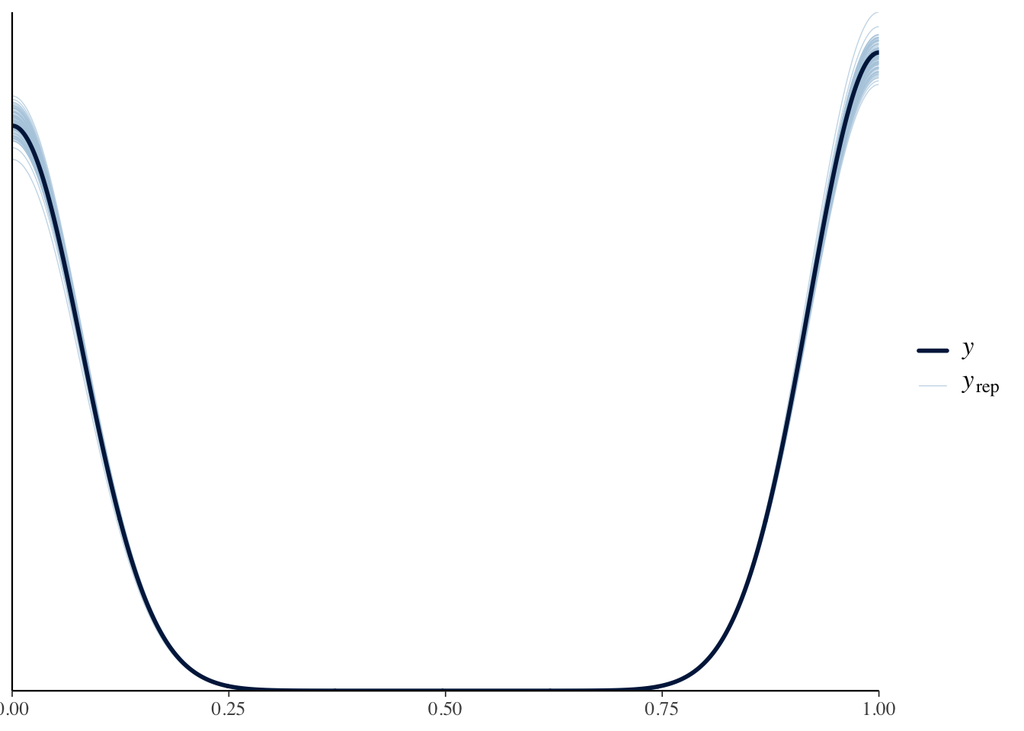

```r
pp_check(E1_mdl, ndraws = 100)
```

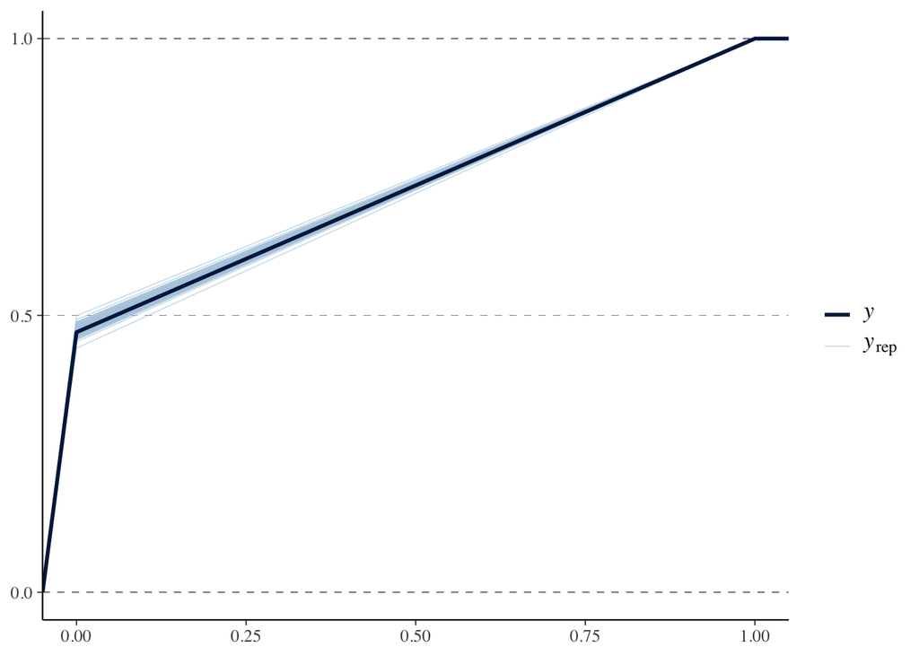

```r
pp_check(E1_mdl, ndraws = 100, type = 'ecdf_overlay')
```

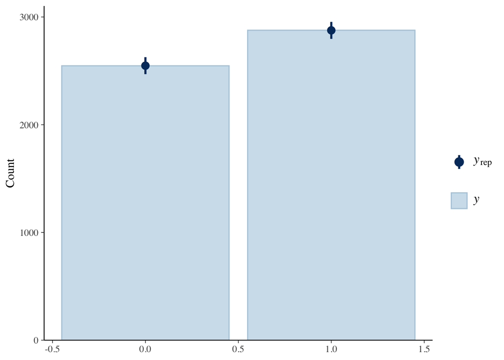

```r
pp_check(E1_mdl, ndraws = 100, type = 'bars')
```

Check neff ratio:

```r
# neff_ratio(E1_mdl)
```

**Note**: Note sure why this doesn’t work. But we have massive number of effective sample sizes anyway (see below).

### 4.3.3 Bayes factor comparisons

Bayes factor comparisons. First, iconicity effect for Experiment 1- three times to assess BF variability:

```r
BF_1 <- bayes_factor(E1_no_icon_mdl, E1_mdl)
BF_2 <- bayes_factor(E1_no_icon_mdl, E1_mdl)
BF_3 <- bayes_factor(E1_no_icon_mdl, E1_mdl)

# Save:

saveRDS(BF_1, '../models/bayes_factors/E1_no_icon_v_full_BF_1.rds')
saveRDS(BF_2, '../models/bayes_factors/E1_no_icon_v_full_BF_2.rds')
saveRDS(BF_3, '../models/bayes_factors/E1_no_icon_v_full_BF_3.rds')
```

Load and show:

```r
BF_1 <- readRDS('../models/bayes_factors/E1_no_icon_v_full_BF_1.rds')
BF_2 <- readRDS('../models/bayes_factors/E1_no_icon_v_full_BF_2.rds')
BF_3 <- readRDS('../models/bayes_factors/E1_no_icon_v_full_BF_3.rds')

# Show:

BF_1
```

```
## Estimated Bayes factor in favor of E1_no_icon_mdl over E1_mdl: 1.28509
```

```r
BF_2
```

```
## Estimated Bayes factor in favor of E1_no_icon_mdl over E1_mdl: 1.22724
```

```r
BF_3
```

```
## Estimated Bayes factor in favor of E1_no_icon_mdl over E1_mdl: 1.15907
```

Second, word class effect for Experiment 1:

```r
BF_1 <- bayes_factor(E1_no_word_class_mdl, E1_mdl)
BF_2 <- bayes_factor(E1_no_word_class_mdl, E1_mdl)
BF_3 <- bayes_factor(E1_no_word_class_mdl, E1_mdl)

# Save:

saveRDS(BF_1, '../models/bayes_factors/E1_no_word_class_v_full_BF_1.rds')
saveRDS(BF_2, '../models/bayes_factors/E1_no_word_class_v_full_BF_2.rds')
saveRDS(BF_3, '../models/bayes_factors/E1_no_word_class_v_full_BF_3.rds')
```

Load and show:

```r
BF_1 <- readRDS('../models/bayes_factors/E1_no_word_class_v_full_BF_1.rds')
BF_2 <- readRDS('../models/bayes_factors/E1_no_word_class_v_full_BF_2.rds')
BF_3 <- readRDS('../models/bayes_factors/E1_no_word_class_v_full_BF_3.rds')

# Show:

BF_1
```

```
## Estimated Bayes factor in favor of E1_no_word_class_mdl over E1_mdl: 2.79956
```

```r
BF_2
```

```
## Estimated Bayes factor in favor of E1_no_word_class_mdl over E1_mdl: 3.04119
```

```r
BF_3
```

```
## Estimated Bayes factor in favor of E1_no_word_class_mdl over E1_mdl: 3.57876
```

### 4.3.4 LOO-CV comparisons

Create loo objects for E1:

```r
E1_loo <- loo(E1_mdl, moment_match = TRUE)
E1_no_icon_loo <- loo(E1_no_icon_mdl, moment_match = TRUE)
E1_no_word_class_loo <- loo(E1_no_word_class_mdl, moment_match = TRUE)

# Save:

saveRDS(E1_loo, '../models/loo_cv_objects/E1_loo.rds')
saveRDS(E1_no_icon_loo, '../models/loo_cv_objects/E1_no_icon_loo.rds')
saveRDS(E1_no_word_class_loo, '../models/loo_cv_objects/E1_no_word_class_loo.rds')
```

Read:

```r
E1_loo <- readRDS('../models/loo_cv_objects/E1_loo.rds')
E1_no_icon_loo <- readRDS('../models/loo_cv_objects/E1_no_icon_loo.rds')
E1_no_word_class_loo <- readRDS('../models/loo_cv_objects/E1_no_word_class_loo.rds')
```

LOO-compare:

```r
# Full versus no icon:

loo_compare(E1_loo, E1_no_icon_loo)
```

```
##                elpd_diff se_diff
## E1_mdl         0.0       0.0
## E1_no_icon_mdl 0.0       0.6
```

```r
# Full versus no word class:

loo_compare(E1_loo, E1_no_word_class_loo)
```

```
##                      elpd_diff se_diff
## E1_no_word_class_mdl  0.0       0.0
## E1_mdl               -0.2       0.4
```

Both factors do not lead to a meaningful change in estimated predictive performance.

### 4.3.5 Interpret model

Look at the model:

```r
E1_mdl
```

```
##  Family: bernoulli
##   Links: mu = logit
## Formula: acc ~ 1 + icon_z + word_class + (1 + icon_z + word_class | participant) + (1 | word)
##    Data: E1 (Number of observations: 5424)
##   Draws: 4 chains, each with iter = 16000; warmup = 4000; thin = 1;
##          total post-warmup draws = 48000
##
## Multilevel Hyperparameters:
## ~participant (Number of levels: 113)
##                                   Estimate Est.Error l-95% CI u-95% CI Rhat
## sd(Intercept)                         0.09      0.05     0.00     0.19 1.00
## sd(icon_z)                            0.05      0.04     0.00     0.14 1.00
## sd(word_classAdj)                     0.10      0.08     0.00     0.30 1.00
## sd(word_classMim)                     0.07      0.05     0.00     0.20 1.00
## sd(word_classVerb)                    0.07      0.06     0.00     0.21 1.00
## cor(Intercept,icon_z)                -0.02      0.35    -0.67     0.65 1.00
## cor(Intercept,word_classAdj)          0.03      0.35    -0.64     0.68 1.00
## cor(icon_z,word_classAdj)             0.04      0.35    -0.64     0.69 1.00
## cor(Intercept,word_classMim)         -0.04      0.35    -0.69     0.64 1.00
## cor(icon_z,word_classMim)            -0.00      0.35    -0.67     0.67 1.00
## cor(word_classAdj,word_classMim)     -0.01      0.35    -0.67     0.66 1.00
## cor(Intercept,word_classVerb)         0.04      0.35    -0.63     0.69 1.00
## cor(icon_z,word_classVerb)           -0.04      0.35    -0.69     0.63 1.00
## cor(word_classAdj,word_classVerb)     0.04      0.35    -0.65     0.69 1.00
## cor(word_classMim,word_classVerb)     0.01      0.35    -0.66     0.68 1.00
##                                   Bulk_ESS Tail_ESS
## sd(Intercept)                        15360    22449
## sd(icon_z)                           23027    26256
## sd(word_classAdj)                    19440    26708
## sd(word_classMim)                    28431    28167
## sd(word_classVerb)                   25378    27539
## cor(Intercept,icon_z)                69735    35965
## cor(Intercept,word_classAdj)         65144    38126
## cor(icon_z,word_classAdj)            52503    39058
## cor(Intercept,word_classMim)         83022    35463
## cor(icon_z,word_classMim)            66202    37909
## cor(word_classAdj,word_classMim)     54675    40005
## cor(Intercept,word_classVerb)        83414    35360
## cor(icon_z,word_classVerb)           61956    39016
## cor(word_classAdj,word_classVerb)    51347    38965
## cor(word_classMim,word_classVerb)    41247    40406
##
## ~word (Number of levels: 100)
##               Estimate Est.Error l-95% CI u-95% CI Rhat Bulk_ESS Tail_ESS
## sd(Intercept)     0.43      0.04     0.34     0.52 1.00    22664    33177
##
## Regression Coefficients:
##                Estimate Est.Error l-95% CI u-95% CI Rhat Bulk_ESS Tail_ESS
## Intercept          0.12      0.07    -0.02     0.25 1.00    46374    39641
## icon_z            -0.06      0.05    -0.15     0.03 1.00    40537    37088
## word_classAdj      0.01      0.09    -0.17     0.20 1.00    51191    38364
## word_classMim     -0.06      0.10    -0.26     0.12 1.00    52148    36792
## word_classVerb     0.02      0.09    -0.16     0.21 1.00    54162    37880
##
## Draws were sampled using sampling(NUTS). For each parameter, Bulk_ESS
## and Tail_ESS are effective sample size measures, and Rhat is the potential
## scale reduction factor on split chains (at convergence, Rhat = 1).
```

### 4.3.6 Posterior probabilities

Compute posterior probabilities for directions (e.g., p(b>0)):

```r
hypothesis(E1_mdl, 'Intercept > 0') # meaningful here as it is the average guessability
```

```
## Hypothesis Tests for class b:
##        Hypothesis Estimate Est.Error CI.Lower CI.Upper Evid.Ratio Post.Prob
## 1 (Intercept) > 0     0.12      0.07        0     0.23      20.11      0.95
##   Star
## 1    *
## ---
## 'CI': 90%-CI for one-sided and 95%-CI for two-sided hypotheses.
## '*': For one-sided hypotheses, the posterior probability exceeds 95%;
## for two-sided hypotheses, the value tested against lies outside the 95%-CI.
## Posterior probabilities of point hypotheses assume equal prior probabilities.
```

```r
hypothesis(E1_mdl, 'icon_z < 0')
```

```
## Hypothesis Tests for class b:
##     Hypothesis Estimate Est.Error CI.Lower CI.Upper Evid.Ratio Post.Prob Star
## 1 (icon_z) < 0    -0.06      0.05    -0.14     0.02       8.49      0.89
## ---
## 'CI': 90%-CI for one-sided and 95%-CI for two-sided hypotheses.
## '*': For one-sided hypotheses, the posterior probability exceeds 95%;
## for two-sided hypotheses, the value tested against lies outside the 95%-CI.
## Posterior probabilities of point hypotheses assume equal prior probabilities.
```

```r
hypothesis(E1_mdl, 'word_classAdj > 0')
```

```
## Hypothesis Tests for class b:
##            Hypothesis Estimate Est.Error CI.Lower CI.Upper Evid.Ratio Post.Prob
## 1 (word_classAdj) > 0     0.01      0.09    -0.14     0.17       1.25      0.56
##   Star
## 1
## ---
## 'CI': 90%-CI for one-sided and 95%-CI for two-sided hypotheses.
## '*': For one-sided hypotheses, the posterior probability exceeds 95%;
## for two-sided hypotheses, the value tested against lies outside the 95%-CI.
## Posterior probabilities of point hypotheses assume equal prior probabilities.
```

```r
hypothesis(E1_mdl, 'word_classMim < 0')
```

```
## Hypothesis Tests for class b:
##            Hypothesis Estimate Est.Error CI.Lower CI.Upper Evid.Ratio Post.Prob
## 1 (word_classMim) < 0    -0.06       0.1    -0.22     0.09       2.89      0.74
##   Star
## 1
## ---
## 'CI': 90%-CI for one-sided and 95%-CI for two-sided hypotheses.
## '*': For one-sided hypotheses, the posterior probability exceeds 95%;
## for two-sided hypotheses, the value tested against lies outside the 95%-CI.
## Posterior probabilities of point hypotheses assume equal prior probabilities.
```

```r
hypothesis(E1_mdl, 'word_classVerb > 0')
```

```
## Hypothesis Tests for class b:
##             Hypothesis Estimate Est.Error CI.Lower CI.Upper Evid.Ratio
## 1 (word_classVerb) > 0     0.02      0.09    -0.13     0.18       1.46
##   Post.Prob Star
## 1      0.59
## ---
## 'CI': 90%-CI for one-sided and 95%-CI for two-sided hypotheses.
## '*': For one-sided hypotheses, the posterior probability exceeds 95%;
## for two-sided hypotheses, the value tested against lies outside the 95%-CI.
## Posterior probabilities of point hypotheses assume equal prior probabilities.
```

All very inconclusive, except for intercept.

The mimetic words are *worse* than the other word classes anyway. The expectation was that they are better. We’ll test for this for E2 as well, and it makes sense to use the meta-analytic average for non-antonym “phonetic symbolism” as a baseline expectation for what is a ROPE.

That is, if ideophones are not better than 53.0% - which was obtained for normal words that weren’t perceived to be iconic, then there’s really nothing special about them from a guessability perspective.

To compute this posterior probability, we need to find the logit value that corresponds to 53%.

```r
logit_val <- log((0.53) / (1 - 0.53))

# Show:

logit_val
```

```
## [1] 0.1201443
```

```r
# Check:

plogis(logit_val)
```

```
## [1] 0.53
```

Then, we need to calculate the prediction for mimetics and see how many of the posterior samples are above this logit value.

```r
hypothesis(E1_mdl, '(Intercept + word_classMim) > 0.1201443')
```

```
## Hypothesis Tests for class b:
##                 Hypothesis Estimate Est.Error CI.Lower CI.Upper Evid.Ratio
## 1 ((Intercept+word_... > 0    -0.07      0.09    -0.21     0.07       0.28
##   Post.Prob Star
## 1      0.22
## ---
## 'CI': 90%-CI for one-sided and 95%-CI for two-sided hypotheses.
## '*': For one-sided hypotheses, the posterior probability exceeds 95%;
## for two-sided hypotheses, the value tested against lies outside the 95%-CI.
## Posterior probabilities of point hypotheses assume equal prior probabilities.
```

Compute the posterior probability that the item SD is bigger than the participant SD. For this `hypothesis()` isn’t set up, so we need to get the draws by hand:

```r
# Extract posterior samples:

E1_posts <- as_draws_df(E1_mdl) |>
  select(sd_participant__Intercept, sd_word__Intercept)
# Show how many of one are more than the other:

sum(E1_posts$sd_word__Intercept > E1_posts$sd_participant__Intercept) / nrow(E1_posts)
```

```
## [1] 1
```

So, a posterior probability of 1.0 that there’s more variation by words than by people.

## 4.4 Experiment 2

### 4.4.1 Fit models

Fit models for E2:

```r
E2_mdl <- brm(acc ~ 1 + icon_z + word_class +
                (1 + icon_z + word_class|participant) +
                (1|word),
              data = E2,
              prior = exp_priors,
              family = bernoulli(link = 'logit'),

              # MCMC settings:

              save_pars = save_pars(all = TRUE),
              cores = 4, chains = 4,
              warmup = 4000, iter = 16000, thin = 1, # 48k for stable bayes factors
              seed = 42)

# No iconicity null model

E2_no_icon_mdl <- brm(acc ~ 1 + word_class +
                (1 + icon_z + word_class|participant) +
                (1|word),
              data = E2,
              prior = exp_priors,
              family = bernoulli(link = 'logit'),

              # MCMC settings:

              save_pars = save_pars(all = TRUE),
              cores = 4, chains = 4,
              warmup = 4000, iter = 16000, thin = 1,
              seed = 42)

# No word class null model:

E2_no_word_class_mdl <- brm(acc ~ 1 + icon_z +
                (1 + icon_z + word_class|participant) +
                (1|word),
              data = E2,
              prior = exp_priors,
              family = bernoulli(link = 'logit'),

              # MCMC settings:

              save_pars = save_pars(all = TRUE),
              cores = 4, chains = 4,
              warmup = 4000, iter = 16000, thin = 1,
              seed = 42)

# Save:

saveRDS(E2_mdl, '../models/E2_mdl.rds')
saveRDS(E2_no_icon_mdl, '../models/E2_no_icon_mdl.rds')
saveRDS(E2_no_word_class_mdl, '../models/E2_no_word_class_mdl.rds')
```

Load:

```r
E2_mdl <- readRDS('../models/E2_mdl.rds')
E2_no_icon_mdl <- readRDS('../models/E2_no_icon_mdl.rds')
E2_no_word_class_mdl <- readRDS('../models/E2_no_word_class_mdl.rds')
```

### 4.4.2 Bayes factor comparisons

Bayes factor comparisons as we did for Experiment 1, but now for E2.

First for iconicity:

```r
BF_1 <- bayes_factor(E2_mdl, E2_no_icon_mdl)
BF_2 <- bayes_factor(E2_mdl, E2_no_icon_mdl)
BF_3 <- bayes_factor(E2_mdl, E2_no_icon_mdl)

# Save:

saveRDS(BF_1, '../models/bayes_factors/E2_no_icon_v_full_BF_1.rds')
saveRDS(BF_2, '../models/bayes_factors/E2_no_icon_v_full_BF_2.rds')
saveRDS(BF_3, '../models/bayes_factors/E2_no_icon_v_full_BF_3.rds')
```

Load and show:

```r
BF_1 <- readRDS('../models/bayes_factors/E2_no_icon_v_full_BF_1.rds')
BF_2 <- readRDS('../models/bayes_factors/E2_no_icon_v_full_BF_2.rds')
BF_3 <- readRDS('../models/bayes_factors/E2_no_icon_v_full_BF_3.rds')

# Show:

BF_1
```

```
## Estimated Bayes factor in favor of E2_mdl over E2_no_icon_mdl: 1.10158
```

```r
BF_2
```

```
## Estimated Bayes factor in favor of E2_mdl over E2_no_icon_mdl: 1.09658
```

```r
BF_3
```

```
## Estimated Bayes factor in favor of E2_mdl over E2_no_icon_mdl: 1.14642
```

Second, for the word class effect:

```r
BF_1 <- bayes_factor(E2_no_word_class_mdl, E2_mdl)
BF_2 <- bayes_factor(E2_no_word_class_mdl, E2_mdl)
BF_3 <- bayes_factor(E2_no_word_class_mdl, E2_mdl)

# Save:

saveRDS(BF_1, '../models/bayes_factors/E2_no_word_class_v_full_BF_1.rds')
saveRDS(BF_2, '../models/bayes_factors/E2_no_word_class_v_full_BF_2.rds')
saveRDS(BF_3, '../models/bayes_factors/E2_no_word_class_v_full_BF_3.rds')
```

Load and show:

```r
BF_1 <- readRDS('../models/bayes_factors/E2_no_word_class_v_full_BF_1.rds')
BF_2 <- readRDS('../models/bayes_factors/E2_no_word_class_v_full_BF_2.rds')
BF_3 <- readRDS('../models/bayes_factors/E2_no_word_class_v_full_BF_3.rds')

# Show:

BF_1
```

```
## Estimated Bayes factor in favor of E2_no_word_class_mdl over E2_mdl: 3.85521
```

```r
BF_2
```

```
## Estimated Bayes factor in favor of E2_no_word_class_mdl over E2_mdl: 2.80722
```

```r
BF_3
```

```
## Estimated Bayes factor in favor of E2_no_word_class_mdl over E2_mdl: 3.63800
```

### 4.4.3 LOO-CV comparisons

Create loo objects for E2:

```r
E2_loo <- loo(E2_mdl, moment_match = TRUE)
E2_no_icon_loo <- loo(E2_no_icon_mdl, moment_match = TRUE)
E2_no_word_class_loo <- loo(E2_no_word_class_mdl, moment_match = TRUE)

# Save:

saveRDS(E2_loo, '../models/loo_cv_objects/E2_loo.rds')
saveRDS(E2_no_icon_loo, '../models/loo_cv_objects/E2_no_icon_loo.rds')
saveRDS(E2_no_word_class_loo, '../models/loo_cv_objects/E2_no_word_class_loo.rds')
```

Read:

```r
E2_loo <- readRDS('../models/loo_cv_objects/E2_loo.rds')
E2_no_icon_loo <- readRDS('../models/loo_cv_objects/E2_no_icon_loo.rds')
E2_no_word_class_loo <- readRDS('../models/loo_cv_objects/E2_no_word_class_loo.rds')
```

LOO-compare:

```r
# Full versus no icon:

loo_compare(E2_loo, E2_no_icon_loo)
```

```
##                elpd_diff se_diff
## E2_mdl          0.0       0.0
## E2_no_icon_mdl -0.2       1.0
```

```r
# Full versus no word class:

loo_compare(E2_loo, E2_no_word_class_loo)
```

```
##                      elpd_diff se_diff
## E2_no_word_class_mdl  0.0       0.0
## E2_mdl               -0.6       0.7
```

Both factors do not lead to a meaningful change in estimated predictive performance.

### 4.4.4 Interpret model

Show the model:

```r
E2_mdl
```

```
##  Family: bernoulli
##   Links: mu = logit
## Formula: acc ~ 1 + icon_z + word_class + (1 + icon_z + word_class | participant) + (1 | word)
##    Data: E2 (Number of observations: 5664)
##   Draws: 4 chains, each with iter = 16000; warmup = 4000; thin = 1;
##          total post-warmup draws = 48000
##
## Multilevel Hyperparameters:
## ~participant (Number of levels: 118)
##                                   Estimate Est.Error l-95% CI u-95% CI Rhat
## sd(Intercept)                         0.08      0.05     0.00     0.19 1.00
## sd(icon_z)                            0.07      0.05     0.00     0.17 1.00
## sd(word_classAdj)                     0.08      0.07     0.00     0.24 1.00
## sd(word_classMim)                     0.08      0.06     0.00     0.23 1.00
## sd(word_classVerb)                    0.08      0.06     0.00     0.23 1.00
## cor(Intercept,icon_z)                -0.07      0.35    -0.70     0.62 1.00
## cor(Intercept,word_classAdj)          0.01      0.35    -0.66     0.67 1.00
## cor(icon_z,word_classAdj)            -0.05      0.35    -0.69     0.63 1.00
## cor(Intercept,word_classMim)         -0.01      0.35    -0.67     0.66 1.00
## cor(icon_z,word_classMim)             0.02      0.35    -0.65     0.68 1.00
## cor(word_classAdj,word_classMim)     -0.01      0.35    -0.67     0.66 1.00
## cor(Intercept,word_classVerb)        -0.00      0.35    -0.66     0.66 1.00
## cor(icon_z,word_classVerb)           -0.02      0.35    -0.68     0.65 1.00
## cor(word_classAdj,word_classVerb)     0.01      0.35    -0.66     0.67 1.00
## cor(word_classMim,word_classVerb)     0.02      0.35    -0.65     0.68 1.00
##                                   Bulk_ESS Tail_ESS
## sd(Intercept)                        13996    23151
## sd(icon_z)                           14903    22910
## sd(word_classAdj)                    23242    26300
## sd(word_classMim)                    23244    25752
## sd(word_classVerb)                   23760    26818
## cor(Intercept,icon_z)                45356    35058
## cor(Intercept,word_classAdj)         75976    35791
## cor(icon_z,word_classAdj)            56201    37734
## cor(Intercept,word_classMim)         82018    37123
## cor(icon_z,word_classMim)            60289    37787
## cor(word_classAdj,word_classMim)     49590    39455
## cor(Intercept,word_classVerb)        82077    35048
## cor(icon_z,word_classVerb)           61089    36765
## cor(word_classAdj,word_classVerb)    51678    39342
## cor(word_classMim,word_classVerb)    44211    37762
##
## ~word (Number of levels: 100)
##               Estimate Est.Error l-95% CI u-95% CI Rhat Bulk_ESS Tail_ESS
## sd(Intercept)     0.23      0.04     0.15     0.32 1.00    20536    27914
##
## Regression Coefficients:
##                Estimate Est.Error l-95% CI u-95% CI Rhat Bulk_ESS Tail_ESS
## Intercept          0.14      0.06     0.03     0.25 1.00    56483    39983
## icon_z             0.05      0.04    -0.02     0.12 1.00    58943    39449
## word_classAdj     -0.06      0.08    -0.22     0.08 1.00    55644    36723
## word_classMim      0.02      0.08    -0.13     0.17 1.00    60950    40563
## word_classVerb     0.02      0.08    -0.12     0.18 1.00    59655    39399
##
## Draws were sampled using sampling(NUTS). For each parameter, Bulk_ESS
## and Tail_ESS are effective sample size measures, and Rhat is the potential
## scale reduction factor on split chains (at convergence, Rhat = 1).
```

### 4.4.5 Posterior probabilities

Compute posterior probabilities for directions (e.g., p(b>0)):

```r
hypothesis(E1_mdl, 'Intercept > 0') # meaningful here as it is the average guessability
```

```
## Hypothesis Tests for class b:
##        Hypothesis Estimate Est.Error CI.Lower CI.Upper Evid.Ratio Post.Prob
## 1 (Intercept) > 0     0.12      0.07        0     0.23      20.11      0.95
##   Star
## 1    *
## ---
## 'CI': 90%-CI for one-sided and 95%-CI for two-sided hypotheses.
## '*': For one-sided hypotheses, the posterior probability exceeds 95%;
## for two-sided hypotheses, the value tested against lies outside the 95%-CI.
## Posterior probabilities of point hypotheses assume equal prior probabilities.
```

```r
hypothesis(E1_mdl, 'icon_z > 0')
```

```
## Hypothesis Tests for class b:
##     Hypothesis Estimate Est.Error CI.Lower CI.Upper Evid.Ratio Post.Prob Star
## 1 (icon_z) > 0    -0.06      0.05    -0.14     0.02       0.12      0.11
## ---
## 'CI': 90%-CI for one-sided and 95%-CI for two-sided hypotheses.
## '*': For one-sided hypotheses, the posterior probability exceeds 95%;
## for two-sided hypotheses, the value tested against lies outside the 95%-CI.
## Posterior probabilities of point hypotheses assume equal prior probabilities.
```

```r
hypothesis(E1_mdl, 'word_classAdj < 0')
```

```
## Hypothesis Tests for class b:
##            Hypothesis Estimate Est.Error CI.Lower CI.Upper Evid.Ratio Post.Prob
## 1 (word_classAdj) < 0     0.01      0.09    -0.14     0.17        0.8      0.44
##   Star
## 1
## ---
## 'CI': 90%-CI for one-sided and 95%-CI for two-sided hypotheses.
## '*': For one-sided hypotheses, the posterior probability exceeds 95%;
## for two-sided hypotheses, the value tested against lies outside the 95%-CI.
## Posterior probabilities of point hypotheses assume equal prior probabilities.
```

```r
hypothesis(E1_mdl, 'word_classMim < 0')
```

```
## Hypothesis Tests for class b:
##            Hypothesis Estimate Est.Error CI.Lower CI.Upper Evid.Ratio Post.Prob
## 1 (word_classMim) < 0    -0.06       0.1    -0.22     0.09       2.89      0.74
##   Star
## 1
## ---
## 'CI': 90%-CI for one-sided and 95%-CI for two-sided hypotheses.
## '*': For one-sided hypotheses, the posterior probability exceeds 95%;
## for two-sided hypotheses, the value tested against lies outside the 95%-CI.
## Posterior probabilities of point hypotheses assume equal prior probabilities.
```

```r
hypothesis(E1_mdl, 'word_classVerb > 0')
```

```
## Hypothesis Tests for class b:
##             Hypothesis Estimate Est.Error CI.Lower CI.Upper Evid.Ratio
## 1 (word_classVerb) > 0     0.02      0.09    -0.13     0.18       1.46
##   Post.Prob Star
## 1      0.59
## ---
## 'CI': 90%-CI for one-sided and 95%-CI for two-sided hypotheses.
## '*': For one-sided hypotheses, the posterior probability exceeds 95%;
## for two-sided hypotheses, the value tested against lies outside the 95%-CI.
## Posterior probabilities of point hypotheses assume equal prior probabilities.
```

All very inconclusive, except for intercept.

We can perform the same comparison of ideophones against a ROPE spanned by +/- `0.1201443`, the logit value corresponding to 53%, which is the non-antonym guessing accuracy from the meta-analysis.

```r
hypothesis(E2_mdl, '(Intercept + word_classMim) > 0.1201443')
```

```
## Hypothesis Tests for class b:
##                 Hypothesis Estimate Est.Error CI.Lower CI.Upper Evid.Ratio
## 1 ((Intercept+word_... > 0     0.04      0.06    -0.07     0.14       2.64
##   Post.Prob Star
## 1      0.73
## ---
## 'CI': 90%-CI for one-sided and 95%-CI for two-sided hypotheses.
## '*': For one-sided hypotheses, the posterior probability exceeds 95%;
## for two-sided hypotheses, the value tested against lies outside the 95%-CI.
## Posterior probabilities of point hypotheses assume equal prior probabilities.
```

Nothing to write home about.

As with E1, compute the posterior probability that the item SD is bigger than the participant SD.

```r
# Extract posterior samples:

E2_posts <- as_draws_df(E2_mdl) |>
  select(sd_participant__Intercept, sd_word__Intercept)
# Show how many of one are more than the other:

sum(E2_posts$sd_word__Intercept > E2_posts$sd_participant__Intercept) / nrow(E1_posts)
```

```
## [1] 0.9889167
```

98.9% of all posterior samples had higher word SDs than participant SDs, which is a posterior probability of p ~ 0.99.

## 4.5 Experiment/task effect

We’ll also do an omnibus analysis combining both experiment to test whether the task leads to a change in guessing accuracy.

### 4.5.1 Prior specification

Here too, we can re-use the same prior - a jump from 50% to 60% in accuracy would be remarkable. So we can re-use the same `class = b` prior as above.

As the iconicity and word class variables did not play any role whatsoever above, we’ll fit the model without that. For the corresponding null model without the `experiment` effect then we need to respecify the priors object without `class = b` since that model is an intercept-only model that has no slopes whatsoever.

```r
both_priors <- c(prior(student_t(3, 0, 0.1274067), class = 'Intercept'),
                 prior(student_t(3, 0, 0.25), class = 'sd', group = 'word'),
                 prior(student_t(3, 0, 0.1274067), class = 'b'),
                 prior(student_t(3, 0, 0.1), class = 'sd', group = 'unique_id'))

exp_null_priors <- c(prior(student_t(3, 0, 0.1274067), class = 'Intercept'),
                     prior(student_t(3, 0, 0.25), class = 'sd', group = 'word'),
                     prior(student_t(3, 0, 0.1), class = 'sd', group = 'unique_id'))
```

### 4.5.2 Create unique identifiers

One thing we need to be careful with is the fact that the participant ids are repeated, which means that the model will treat as a within-participants factor if we don’t create unique identifiers. We can do this by simply pasting the `experiment` column together with the `participant` column.

```r
both <- both |>
  mutate(unique_id = str_c(experiment, '_', participant))
```

### 4.5.3 Fit model

Fit the combined model:

```r
# Full model:

both_mdl <- brm(acc ~ 1 + experiment +
                (1|unique_id) +
                (1|word),
              data = both,
              prior = both_priors,
              family = bernoulli(link = 'logit'),

              # MCMC settings:

              save_pars = save_pars(all = TRUE),
              cores = 4, chains = 4,
              warmup = 4000, iter = 16000, thin = 1, # 48k for stable bayes factors
              seed = 42)

# Null model:

both_no_experiment_mdl <- brm(acc ~ 1 +
                                (1|unique_id) +
                                (1|word),
                              data = both,
                              prior = exp_null_priors,
                              family = bernoulli(link = 'logit'),

              # MCMC settings:

              save_pars = save_pars(all = TRUE),
              cores = 4, chains = 4,
              warmup = 4000, iter = 16000, thin = 1, # 48k for stable bayes factors
              seed = 42)

# Save:

saveRDS(both_mdl, '../models/both_mdl.rds')
saveRDS(both_no_experiment_mdl, '../models/both_no_experiment_mdl.rds')
```

Load:

```r
both_mdl <- readRDS('../models/both_mdl.rds')
both_no_experiment_mdl <- readRDS('../models/both_no_experiment_mdl.rds')
```

### 4.5.4 Bayes factor comparison

Perform Bayes factor comparison of model with experiment effect against model without:

```r
BF_1 <- bayes_factor(both_no_experiment_mdl, both_mdl)
BF_2 <- bayes_factor(both_no_experiment_mdl, both_mdl)
BF_3 <- bayes_factor(both_no_experiment_mdl, both_mdl)

# Save:

saveRDS(BF_1, '../models/bayes_factors/both_no_experiment_v_full_BF_1.rds')
saveRDS(BF_2, '../models/bayes_factors/both_no_experiment_v_full_BF_2.rds')
saveRDS(BF_3, '../models/bayes_factors/both_no_experiment_v_full_BF_3.rds')
```

Load and show:

```r
BF_1 <- readRDS('../models/bayes_factors/both_no_experiment_v_full_BF_1.rds')
BF_2 <- readRDS('../models/bayes_factors/both_no_experiment_v_full_BF_2.rds')
BF_3 <- readRDS('../models/bayes_factors/both_no_experiment_v_full_BF_3.rds')

# Show:

BF_1
```

```
## Estimated Bayes factor in favor of both_no_experiment_mdl over both_mdl: 3.30670
```

```r
BF_2
```

```
## Estimated Bayes factor in favor of both_no_experiment_mdl over both_mdl: 3.27750
```

```r
BF_3
```

```
## Estimated Bayes factor in favor of both_no_experiment_mdl over both_mdl: 3.24590
```

### 4.5.5 LOO-CV comparisons

Create loo objects for the combined models:

```r
both_loo <- loo(both_mdl, moment_match = TRUE)
both_no_experiment_loo <- loo(both_no_experiment_mdl, moment_match = TRUE)

# Save:

saveRDS(both_loo, '../models/loo_cv_objects/both_loo.rds')
saveRDS(both_no_experiment_loo, '../models/loo_cv_objects/both_no_experiment_loo.rds')
```

Read:

```r
both_loo <- readRDS('../models/loo_cv_objects/both_loo.rds')
both_no_experiment_loo <- readRDS('../models/loo_cv_objects/both_no_experiment_loo.rds')
```

LOO-compare:

```r
loo_compare(both_loo, both_no_experiment_loo)
```

```
##                        elpd_diff se_diff
## both_no_experiment_mdl  0.0       0.0
## both_mdl               -0.8       0.4
```

### 4.5.6 Interpret model

Show the model:

```r
both_mdl
```

```
##  Family: bernoulli
##   Links: mu = logit
## Formula: acc ~ 1 + experiment + (1 | unique_id) + (1 | word)
##    Data: both (Number of observations: 11088)
##   Draws: 4 chains, each with iter = 16000; warmup = 4000; thin = 1;
##          total post-warmup draws = 48000
##
## Multilevel Hyperparameters:
## ~unique_id (Number of levels: 231)
##               Estimate Est.Error l-95% CI u-95% CI Rhat Bulk_ESS Tail_ESS
## sd(Intercept)     0.09      0.04     0.01     0.18 1.00     9954    13767
##
## ~word (Number of levels: 100)
##               Estimate Est.Error l-95% CI u-95% CI Rhat Bulk_ESS Tail_ESS
## sd(Intercept)     0.29      0.03     0.24     0.36 1.00    22824    33589
##
## Regression Coefficients:
##                             Estimate Est.Error l-95% CI u-95% CI Rhat Bulk_ESS
## Intercept                       0.12      0.04     0.04     0.20 1.00    33885
## experimentmeaningMtoMformE2     0.02      0.04    -0.06     0.09 1.00    95199
##                             Tail_ESS
## Intercept                      38553
## experimentmeaningMtoMformE2    37404
##
## Draws were sampled using sampling(NUTS). For each parameter, Bulk_ESS
## and Tail_ESS are effective sample size measures, and Rhat is the potential
## scale reduction factor on split chains (at convergence, Rhat = 1).
```

### 4.5.7 Posterior probabilities

Compute posterior probabilities of direction:

```r
hypothesis(both_mdl, 'Intercept > 0')
```

```
## Hypothesis Tests for class b:
##        Hypothesis Estimate Est.Error CI.Lower CI.Upper Evid.Ratio Post.Prob
## 1 (Intercept) > 0     0.12      0.04     0.05     0.18      488.8         1
##   Star
## 1    *
## ---
## 'CI': 90%-CI for one-sided and 95%-CI for two-sided hypotheses.
## '*': For one-sided hypotheses, the posterior probability exceeds 95%;
## for two-sided hypotheses, the value tested against lies outside the 95%-CI.
## Posterior probabilities of point hypotheses assume equal prior probabilities.
```

```r
hypothesis(both_mdl, 'experimentmeaningMtoMformE2 > 0')
```

```
## Hypothesis Tests for class b:
##                 Hypothesis Estimate Est.Error CI.Lower CI.Upper Evid.Ratio
## 1 (experimentmeanin... > 0     0.02      0.04    -0.05     0.08       1.94
##   Post.Prob Star
## 1      0.66
## ---
## 'CI': 90%-CI for one-sided and 95%-CI for two-sided hypotheses.
## '*': For one-sided hypotheses, the posterior probability exceeds 95%;
## for two-sided hypotheses, the value tested against lies outside the 95%-CI.
## Posterior probabilities of point hypotheses assume equal prior probabilities.
```

## 4.6 Combined analysis with interaction

For the iconicity effect, it would be good to have the most power to estimate it, which means combining the data from both experiments - it’s likely *not* going to show a consistent iconicity effect since we’ve already seen that E1 and E2 have iconicity effects of differing signs. More importantly, we want to formally test the interaction between the two. We also want to see whether there is any evidence for a word class effect if we have more power. If word class is included and we’re now testing for the interaction, we don’t want the corresponding coefficient to only be there for the noun reference level. So it makes sense to sum-code the `word_class` predictor so that things are the grand mean here:

```r
both <- both |>
  mutate(word_class_sum = factor(word_class))

# Change:

contrasts(both$word_class_sum) <- contr.sum(4)

# Check:

contrasts(both$word_class_sum)
```

```
##      [,1] [,2] [,3]
## Noun    1    0    0
## Adj     0    1    0
## Mim     0    0    1
## Verb   -1   -1   -1
```

The above-specified prior will be a bit more diffuse for this sum-coded predictor relative to the previously treatment-coded predictor, but that’s ok- no need to really change this.

Let’s also sum-code the experiment predictor. Here things are balanced, so we can use standard contrasts:

```r
both <- both |>
  mutate(experiment = factor(experiment,
                             levels = c('form-to-meaning (E1)',
                                        'meaning-to-form (E2)')))

contrasts(both$experiment) <- contr.sum(2)
```

We’ve rename the `participant` variable to `unique_id` though, so our prior object needs to reflect this as well:

```r
exp_priors <- c(prior(student_t(3, 0, 0.1274067), class = 'Intercept'),
                prior(student_t(3, 0, 0.1274067), class = 'b'),
                prior(student_t(3, 0, 0.25), class = 'sd', group = 'word'),
                prior(student_t(3, 0, 0.1), class = 'sd', group = 'unique_id'),
                prior(lkj(2), class = 'cor'))
```

### 4.6.1 Fit models

Fit the models:

```r
# Full model:

both_interact_mdl <- brm(acc ~ 1 + experiment +
                           icon_z + experiment:icon_z +
                           word_class_sum +
                           (1 + icon_z + word_class_sum|unique_id) +
                           (1|word),
                         data = both,
                         prior = exp_priors,
                         family = bernoulli(link = 'logit'),

                         # MCMC settings:

                         save_pars = save_pars(all = TRUE),
                         cores = 4, chains = 4,
                         warmup = 4000, iter = 16000, thin = 1,
                         seed = 42)

# Null model without interaction:

both_no_interact_mdl <- brm(acc ~ 1 + experiment +
                              icon_z +
                              word_class_sum +
                              (1 + icon_z + word_class_sum|unique_id) +
                              (1|word),
                            data = both,
                            prior = exp_priors,
                            family = bernoulli(link = 'logit'),

                            # MCMC settings:

                            save_pars = save_pars(all = TRUE),
                            cores = 4, chains = 4,
                            warmup = 4000, iter = 16000, thin = 1,
                            seed = 42)

# Null model without word class effect:

both_no_word_class_mdl <- brm(acc ~ 1 + experiment +
                                icon_z +
                                (1 + icon_z + word_class_sum|unique_id) +
                                (1|word),
                              data = both,
                              prior = exp_priors,
                              family = bernoulli(link = 'logit'),

                              # MCMC settings:

                              save_pars = save_pars(all = TRUE),
                              cores = 4, chains = 4,
                              warmup = 4000, iter = 16000, thin = 1,
                              seed = 42)

# Null model without iconicity effect:

both_no_icon_mdl <- brm(acc ~ 1 + experiment +
                          word_class_sum +
                          (1 + icon_z + word_class_sum|unique_id) +
                          (1|word),
                        data = both,
                        prior = exp_priors,
                        family = bernoulli(link = 'logit'),

                        # MCMC settings:

                        save_pars = save_pars(all = TRUE),
                        cores = 4, chains = 4,
                        warmup = 4000, iter = 16000, thin = 1,
                        seed = 42)

# Save:

saveRDS(both_interact_mdl, '../models/both_interact_mdl.rds')
saveRDS(both_no_interact_mdl, '../models/both_no_interact_mdl.rds')
saveRDS(both_no_word_class_mdl, '../models/both_no_word_class_mdl.rds')
saveRDS(both_no_icon_mdl, '../models/both_no_icon_mdl.rds')
```

Load models:

```r
both_interact_mdl <- readRDS('../models/both_interact_mdl.rds')
both_no_interact_mdl <- readRDS('../models/both_no_interact_mdl.rds')
both_no_word_class_mdl <- readRDS('../models/both_no_word_class_mdl.rds')
both_no_icon_mdl <- readRDS('../models/both_no_icon_mdl.rds')
```

### 4.6.2 Bayes factors

First, for the interaction:

```r
BF_1 <- bayes_factor(both_interact_mdl, both_no_interact_mdl)
BF_2 <- bayes_factor(both_interact_mdl, both_no_interact_mdl)
BF_3 <- bayes_factor(both_interact_mdl, both_no_interact_mdl)

# Save:

saveRDS(BF_1, '../models/bayes_factors/both_interact_v_no_interact_BF_1.rds')
saveRDS(BF_2, '../models/bayes_factors/both_interact_v_no_interact_BF_2.rds')
saveRDS(BF_3, '../models/bayes_factors/both_interact_v_no_interact_BF_3.rds')
```

Load and show:

```r
BF_1 <- readRDS('../models/bayes_factors/both_interact_v_no_interact_BF_1.rds')
BF_2 <- readRDS('../models/bayes_factors/both_interact_v_no_interact_BF_2.rds')
BF_3 <- readRDS('../models/bayes_factors/both_interact_v_no_interact_BF_3.rds')

# Show:

BF_1
```

```
## Estimated Bayes factor in favor of both_interact_mdl over both_no_interact_mdl: 10829560.50296
```

```r
BF_2
```

```
## Estimated Bayes factor in favor of both_interact_mdl over both_no_interact_mdl: 2138222.66047
```

```r
BF_3
```

```
## Estimated Bayes factor in favor of both_interact_mdl over both_no_interact_mdl: 53383806.83858
```

Second, the iconicity effect:

```r
BF_1 <- bayes_factor(both_no_icon_mdl, both_no_interact_mdl)
BF_2 <- bayes_factor(both_no_icon_mdl, both_no_interact_mdl)
BF_3 <- bayes_factor(both_no_icon_mdl, both_no_interact_mdl)

# Save:

saveRDS(BF_1, '../models/bayes_factors/both_no_icon_v_no_interact_BF_1.rds')
saveRDS(BF_2, '../models/bayes_factors/both_no_icon_v_no_interact_BF_2.rds')
saveRDS(BF_3, '../models/bayes_factors/both_no_icon_v_no_interact_BF_3.rds')
```

Load and show:

```r
BF_1 <- readRDS('../models/bayes_factors/both_no_icon_v_no_interact_BF_1.rds')
BF_2 <- readRDS('../models/bayes_factors/both_no_icon_v_no_interact_BF_2.rds')
BF_3 <- readRDS('../models/bayes_factors/both_no_icon_v_no_interact_BF_3.rds')

# Show:

BF_1
```

```
## Estimated Bayes factor in favor of both_no_icon_mdl over both_no_interact_mdl: 5941.95143
```

```r
BF_2
```

```
## Estimated Bayes factor in favor of both_no_icon_mdl over both_no_interact_mdl: 3950.78104
```

```r
BF_3
```

```
## Estimated Bayes factor in favor of both_no_icon_mdl over both_no_interact_mdl: 66514.75811
```

Third, the word class effect:

```r
BF_1 <- bayes_factor(both_no_word_class_mdl, both_no_interact_mdl)
BF_2 <- bayes_factor(both_no_word_class_mdl, both_no_interact_mdl)
BF_3 <- bayes_factor(both_no_word_class_mdl, both_no_interact_mdl)

# Save:

saveRDS(BF_1, '../models/bayes_factors/both_no_word_class_v_no_interact_BF_1.rds')
saveRDS(BF_2, '../models/bayes_factors/both_no_word_class_v_no_interact_BF_2.rds')
saveRDS(BF_3, '../models/bayes_factors/both_no_word_class_v_no_interact_BF_3.rds')
```

Load and show:

```r
BF_1 <- readRDS('../models/bayes_factors/both_no_word_class_v_no_interact_BF_1.rds')
BF_2 <- readRDS('../models/bayes_factors/both_no_word_class_v_no_interact_BF_2.rds')
BF_3 <- readRDS('../models/bayes_factors/both_no_word_class_v_no_interact_BF_3.rds')

# Show:

BF_1
```

```
## Estimated Bayes factor in favor of both_no_word_class_mdl over both_no_interact_mdl: 2.30472
```

```r
BF_2
```

```
## Estimated Bayes factor in favor of both_no_word_class_mdl over both_no_interact_mdl: 0.15572
```

```r
BF_3
```

```
## Estimated Bayes factor in favor of both_no_word_class_mdl over both_no_interact_mdl: 0.80005
```

### 4.6.3 LOO-CV

LOO-CV objects:

```r
both_interact_loo <- loo(both_interact_mdl, moment_match = TRUE)
both_no_interact_loo <- loo(both_no_interact_mdl, moment_match = TRUE)
both_no_word_class_loo <- loo(both_no_word_class_mdl, moment_match = TRUE)
both_no_icon_loo <- loo(both_no_icon_mdl, moment_match = TRUE)

# Save:

saveRDS(both_interact_loo, '../models/loo_cv_objects/both_interact_loo.rds')
saveRDS(both_no_interact_loo, '../models/loo_cv_objects/both_no_interact_loo.rds')
saveRDS(both_no_word_class_loo, '../models/loo_cv_objects/both_no_word_class_loo.rds')
saveRDS(both_no_icon_loo, '../models/loo_cv_objects/both_no_icon_loo.rds')
```

Read:

```r
both_interact_loo <- readRDS('../models/loo_cv_objects/both_interact_loo.rds')
both_no_interact_loo <- readRDS('../models/loo_cv_objects/both_no_interact_loo.rds')
both_no_word_class_loo <- readRDS('../models/loo_cv_objects/both_no_word_class_loo.rds')
both_no_icon_loo <- readRDS('../models/loo_cv_objects/both_no_icon_loo.rds')
```

LOO-CV compare:

```r
# Interaction versus no interaction:

loo_compare(both_interact_loo, both_no_interact_loo)
```

```
##                      elpd_diff se_diff
## both_interact_mdl     0.0       0.0
## both_no_interact_mdl -4.3       2.8
```

```r
# No interaction versus iconicity:

loo_compare(both_no_interact_loo, both_no_icon_loo)
```

```
##                      elpd_diff se_diff
## both_no_icon_mdl      0.0       0.0
## both_no_interact_mdl -0.2       0.1
```

```r
# No interaction versus word_class:

loo_compare(both_no_interact_loo, both_no_word_class_loo)
```

```
##                        elpd_diff se_diff
## both_no_word_class_mdl  0.0       0.0
## both_no_interact_mdl   -0.5       0.4
```

### 4.6.4 Interpret model

Show the model:

```r
both_interact_mdl
```

```
##  Family: bernoulli
##   Links: mu = logit
## Formula: acc ~ 1 + experiment + icon_z + experiment:icon_z + word_class_sum + (1 + icon_z + word_class_sum | unique_id) + (1 | word)
##    Data: both (Number of observations: 11088)
##   Draws: 4 chains, each with iter = 16000; warmup = 4000; thin = 1;
##          total post-warmup draws = 48000
##
## Multilevel Hyperparameters:
## ~unique_id (Number of levels: 231)
##                                      Estimate Est.Error l-95% CI u-95% CI Rhat
## sd(Intercept)                            0.09      0.05     0.01     0.18 1.00
## sd(icon_z)                               0.06      0.04     0.00     0.13 1.00
## sd(word_class_sum1)                      0.05      0.04     0.00     0.14 1.00
## sd(word_class_sum2)                      0.05      0.04     0.00     0.14 1.00
## sd(word_class_sum3)                      0.05      0.03     0.00     0.13 1.00
## cor(Intercept,icon_z)                   -0.09      0.34    -0.70     0.59 1.00
## cor(Intercept,word_class_sum1)          -0.03      0.35    -0.68     0.64 1.00
## cor(icon_z,word_class_sum1)              0.02      0.35    -0.65     0.67 1.00
## cor(Intercept,word_class_sum2)           0.02      0.35    -0.65     0.67 1.00
## cor(icon_z,word_class_sum2)              0.04      0.35    -0.64     0.68 1.00
## cor(word_class_sum1,word_class_sum2)    -0.03      0.35    -0.68     0.64 1.00
## cor(Intercept,word_class_sum3)          -0.07      0.35    -0.70     0.62 1.00
## cor(icon_z,word_class_sum3)              0.04      0.35    -0.64     0.69 1.00
## cor(word_class_sum1,word_class_sum3)    -0.04      0.36    -0.70     0.64 1.00
## cor(word_class_sum2,word_class_sum3)    -0.06      0.36    -0.72     0.63 1.00
##                                      Bulk_ESS Tail_ESS
## sd(Intercept)                            7980    12093
## sd(icon_z)                              10964    19395
## sd(word_class_sum1)                     19012    23239
## sd(word_class_sum2)                     17641    23708
## sd(word_class_sum3)                     19445    22106
## cor(Intercept,icon_z)                   32613    33395
## cor(Intercept,word_class_sum1)          56951    35095
## cor(icon_z,word_class_sum1)             49841    37527
## cor(Intercept,word_class_sum2)          55246    36582
## cor(icon_z,word_class_sum2)             46870    37405
## cor(word_class_sum1,word_class_sum2)    42797    39620
## cor(Intercept,word_class_sum3)          57041    36884
## cor(icon_z,word_class_sum3)             51536    37151
## cor(word_class_sum1,word_class_sum3)    46913    38875
## cor(word_class_sum2,word_class_sum3)    38709    39044
##
## ~word (Number of levels: 100)
##               Estimate Est.Error l-95% CI u-95% CI Rhat Bulk_ESS Tail_ESS
## sd(Intercept)     0.30      0.03     0.24     0.37 1.00    21583    33147
##
## Regression Coefficients:
##                    Estimate Est.Error l-95% CI u-95% CI Rhat Bulk_ESS Tail_ESS
## Intercept              0.13      0.04     0.06     0.20 1.00    21715    32054
## experiment1           -0.01      0.02    -0.05     0.03 1.00    76464    37045
## icon_z                -0.00      0.03    -0.07     0.06 1.00    22796    30511
## word_class_sum1        0.01      0.05    -0.10     0.12 1.00    24826    32158
## word_class_sum2       -0.02      0.05    -0.13     0.08 1.00    24522    33221
## word_class_sum3       -0.02      0.05    -0.13     0.09 1.00    25049    33554
## experiment1:icon_z    -0.06      0.02    -0.10    -0.02 1.00    84078    36767
##
## Draws were sampled using sampling(NUTS). For each parameter, Bulk_ESS
## and Tail_ESS are effective sample size measures, and Rhat is the potential
## scale reduction factor on split chains (at convergence, Rhat = 1).
```

### 4.6.5 Posterior probabilities

Compute the posterior probability of an average effect:

```r
hypothesis(both_interact_mdl, 'Intercept > 0')
```

```
## Hypothesis Tests for class b:
##        Hypothesis Estimate Est.Error CI.Lower CI.Upper Evid.Ratio Post.Prob
## 1 (Intercept) > 0     0.13      0.04     0.07     0.18    3427.57         1
##   Star
## 1    *
## ---
## 'CI': 90%-CI for one-sided and 95%-CI for two-sided hypotheses.
## '*': For one-sided hypotheses, the posterior probability exceeds 95%;
## for two-sided hypotheses, the value tested against lies outside the 95%-CI.
## Posterior probabilities of point hypotheses assume equal prior probabilities.
```

We still have the logit value that corresponds to the meta-analytic average of non-antonym studies.

```r
logit_val
```

```
## [1] 0.1201443
```

```r
plogis(logit_val)
```

```
## [1] 0.53
```

This is the descriptive average. Check that the ideophones are above that:

```r
hypothesis(both_interact_mdl, 'Intercept + word_class_sum3 > 0.1201443')
```

```
## Hypothesis Tests for class b:
##                 Hypothesis Estimate Est.Error CI.Lower CI.Upper Evid.Ratio
## 1 (Intercept+word_c... > 0    -0.01      0.07    -0.12     0.09       0.69
##   Post.Prob Star
## 1      0.41
## ---
## 'CI': 90%-CI for one-sided and 95%-CI for two-sided hypotheses.
## '*': For one-sided hypotheses, the posterior probability exceeds 95%;
## for two-sided hypotheses, the value tested against lies outside the 95%-CI.
## Posterior probabilities of point hypotheses assume equal prior probabilities.
```

We can also check against the model average (`mean(posts_int$no_antonyms)` from the meta-analysis script is `55.06998`), and that’s gonna be even worse.

```r
# Find the logit value:

p <- 55.06998 / 100
log(p / (1 -p))
```

```
## [1] 0.2034986
```

```r
# Check against that:

hypothesis(both_interact_mdl, 'Intercept + word_class_sum3 > 0.2034986')
```

```
## Hypothesis Tests for class b:
##                 Hypothesis Estimate Est.Error CI.Lower CI.Upper Evid.Ratio
## 1 (Intercept+word_c... > 0     -0.1      0.07     -0.2     0.01       0.07
##   Post.Prob Star
## 1      0.06
## ---
## 'CI': 90%-CI for one-sided and 95%-CI for two-sided hypotheses.
## '*': For one-sided hypotheses, the posterior probability exceeds 95%;
## for two-sided hypotheses, the value tested against lies outside the 95%-CI.
## Posterior probabilities of point hypotheses assume equal prior probabilities.
```

Compute the posterior probability that the item SD is bigger than the participant SD:

```r
# Extract posterior samples:

both_posts <- as_draws_df(both_interact_mdl) |>
  select(sd_unique_id__Intercept, sd_word__Intercept)
# Show how many of one are more than the other:

sum(both_posts$sd_word__Intercept > both_posts$sd_unique_id__Intercept) / nrow(both_posts)
```

```
## [1] 0.9999792
```

## 4.7 Data and model visualization

Let’s make a plot of the 100 items with their descriptive accuracy and 95% credible intervals.

### 4.7.1 Set up posterior draws

For the item-level 95% CrI’s, we’ll use `both_mdl`, as this has the most power.

Extract the posterior values of the word intercepts (random effects levels):

```r
word_posts <- coef(both_mdl)$word[, , 1]

# Show:

word_posts
```

```
##                Estimate Est.Error         Q2.5        Q97.5
## betsuna    -0.067786781 0.1681894 -0.397804546  0.260410366
## burari     -0.131694914 0.1598241 -0.445152234  0.180607493
## busuri     -0.484318361 0.1729678 -0.829791442 -0.150758880
## buwabuwa    0.007181112 0.1628365 -0.312519562  0.322059700
## chikaku    -0.265053034 0.1684359 -0.601621913  0.063369963
## chirochiro  0.481462697 0.1598795  0.170244773  0.799951922
## debudebu   -0.155533602 0.1665538 -0.484445720  0.169267493
## fukameru   -0.324506115 0.1690765 -0.660627251  0.002800926
## funyafunya  0.400892413 0.1573242  0.097839735  0.711770772
## furina     -0.338078343 0.1528963 -0.641365645 -0.041729605
## furui       0.148231766 0.1558892 -0.155633579  0.454241258
## futsufutsu  0.302148009 0.1714718 -0.031522399  0.640847540
## gakun       0.007238981 0.1613034 -0.311097603  0.322522352
## garan       0.725549914 0.1805904  0.377322728  1.088659747
## gatan       0.228377479 0.1565945 -0.078979726  0.535125562
## goshagosha  0.390302038 0.1634000  0.073389523  0.714961273
## gusha      -0.060043210 0.1597549 -0.375285328  0.251937131
## haha        0.183915622 0.1604361 -0.128440820  0.500838518
## hajimeru    0.117599569 0.1593464 -0.196741832  0.428110737
## hana        0.616663542 0.1796127  0.271164128  0.974581346
## hanashi     0.046329011 0.1706716 -0.287208865  0.380899162
## harari      0.123568359 0.1560281 -0.182510672  0.429901303
## hayamena    0.015229400 0.1585898 -0.296820152  0.325124535
## hikari      0.453500997 0.1700460  0.123498717  0.791147514
## hiku        0.427655087 0.1596753  0.115618595  0.744249370
## hiratai    -0.148634322 0.1548500 -0.454990919  0.153592828
## hirogeru    0.170431957 0.1691230 -0.160387514  0.503381057
## hiroi       0.124869501 0.1634966 -0.197089829  0.445623232
## hitoshii    0.034988645 0.1682360 -0.293782171  0.364939288
## hitotsu    -0.363331176 0.1618454 -0.684168416 -0.049157943
## hiyohiyo    0.237976888 0.1679251 -0.088313931  0.569961371
## hoka        0.004443907 0.1644249 -0.320826801  0.327991514
## jimoto      0.133299545 0.1736956 -0.204870893  0.472865513
## kagiri     -0.116173350 0.1569532 -0.426839624  0.191560746
## kako        0.469862290 0.1737744  0.133536597  0.815199277
## karari      0.169226007 0.1662508 -0.156545462  0.498952215
## kasanaru   -0.052696035 0.1534298 -0.354494922  0.246038614
## kasaneru   -0.022450591 0.1590317 -0.333053800  0.289010486
## katachi     0.196729216 0.1617599 -0.120682381  0.515104953
```

[output cut: 46 more lines]

```
## toboshii    0.311334829 0.1608219 -0.003526065  0.627802046
## tobu        0.420060520 0.1684451  0.092549861  0.754563477
## tochi       0.120680264 0.1562094 -0.184647256  0.427815876
## tomonau     0.239371558 0.1535937 -0.060623711  0.543284453
## tsubuyaku   0.213345836 0.1681405 -0.112845262  0.547452758
## tsuma       0.222448250 0.1562240 -0.081928653  0.528191681
## tsuratsura  0.472880528 0.1652800  0.154243671  0.804076482
## tsuyoi      0.340126910 0.1655916  0.018395020  0.669058035
## wasawasa    0.090724586 0.1569102 -0.217132363  0.398845617
## wasureru    0.221094320 0.1529705 -0.075075392  0.521747785
## yobu        0.355479246 0.1654601  0.031424496  0.680545413
## yomu        0.389988462 0.1723216  0.053891848  0.731514914
## yuku        0.519379664 0.1681359  0.196536388  0.853594016
## yume        0.247643886 0.1549860 -0.055890322  0.552394426
## yutakana   -0.345955995 0.1696201 -0.681617864 -0.016217923
```

Make this into a tibble and make the row names into a column that we can index:

```r
word_posts <- word_posts |>
  as.data.frame() |>
  rownames_to_column('word')
```

Add the word class information back into there, as well as from the `items` tibble the iconicity quantile:

```r
word_posts <- word_posts |>
  left_join(distinct(E1, word, word_class),
            by = c('word' = 'word')) |>
  relocate(word_class, .after = word) |>
  left_join(distinct(items, romaji, quantile),
            by = c('word' = 'romaji')) |>
  relocate(quantile, .after = word_class)
```

We’ll also want to plot descriptive means to make sure the picture isn’t tainted too much by shrinkage / so as to not to artificially deflate variation and suggest that results are more consistent as they are.

```r
word_posts <- left_join(word_posts, acc_item_avgs_both,
                        by = c('word' = 'word'))
```

Sort the tibble by `Estimate` (posterior mean accuracy) and code the word factor with the levels in that order so that we don’t have to use `reorder()` for the ggplot2 below:

```r
word_posts <- word_posts |> arrange(Estimate)

# Factor code:

word_posts <- word_posts |>
  mutate(word = factor(word, levels = word_posts$word))
```

It will be more intuitive for most audiences to plot this in probability space.

```r
word_posts <- word_posts |>
  mutate(estimate = plogis(Estimate),
         lower_ci = plogis(Q2.5),
         upper_ci = plogis(Q97.5))
```

### 4.7.2 Plot sequence for Evolang presentation

Make a plot of the posterior draws first:

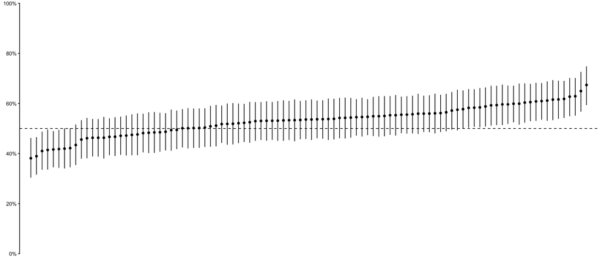

```r
# Plot core:

word_p <- word_posts |>
  ggplot(aes(x = word, y = estimate)) +
  geom_point() +
  geom_segment(aes(y = lower_ci, yend = upper_ci)) +
  geom_hline(linetype = 'dashed', yintercept = 0.5)

# Axes and cosmetics:

word_p <- word_p +
  scale_x_discrete(expand = c(0.02, 0.02)) +
  scale_y_continuous(limits = c(0, 1.0),
                     breaks = seq(0, 1, 0.2),
                     expand = c(0, 0),
                     labels = str_c(seq(0, 100, 20), '%')) +
  xlab(NULL) +
  ylab(NULL) +
  theme_classic() +
  theme(axis.line.x = element_blank(),
        axis.text.x = element_blank(),
        axis.ticks.x = element_blank())

# Show and save:

word_p
```

```r
ggsave(plot = word_p, filename = '../figures/png/word_posteriors.png',
       width = 12, height = 5)
ggsave(plot = word_p, filename = '../figures/pdf/word_posteriors.pdf',
       width = 12, height = 5)
```

Plot the same thing with added descriptive means on there:

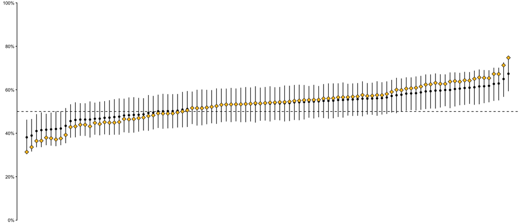

```r
# Plot core:

word_p <- word_posts |>
  ggplot(aes(x = word, y = estimate)) +
  geom_point() +
  geom_segment(aes(y = lower_ci, yend = upper_ci)) +
  geom_hline(linetype = 'dashed', yintercept = 0.5) +
  geom_point(aes(y = acc_mean),
             shape = 23, fill = 'goldenrod1',
             size = 2.5)

# Axes and cosmetics:

word_p <- word_p +
  scale_x_discrete(expand = c(0.02, 0.02)) +
  scale_y_continuous(limits = c(0, 1.0),
                     breaks = seq(0, 1, 0.2),
                     expand = c(0, 0),
                     labels = str_c(seq(0, 100, 20), '%')) +
  xlab(NULL) +
  ylab(NULL) +
  theme_classic() +
  theme(axis.line.x = element_blank(),
        axis.text.x = element_blank(),
        axis.ticks.x = element_blank())

# Show and save:

word_p
```

```r
ggsave(plot = word_p, filename = '../figures/png/word_posteriors_with_descriptive_means.png',
       width = 12, height = 5)
ggsave(plot = word_p, filename = '../figures/pdf/word_posteriors_with_descriptive_means.pdf',
       width = 12, height = 5)
```

For Evolang presentation, we’ll toggle through this and highlight the different word classes, as well as the highest iconicity quantile (quantile = 5).

Quantile highlight:

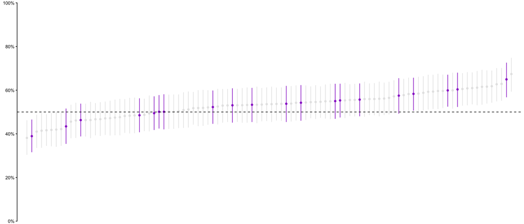

```r
# Plot core:

word_p <- word_posts |>
  mutate(high_quantile = if_else(quantile == '5', 'high iconicity', 'other'),
         high_quantile = factor(high_quantile, levels = c('other', 'high iconicity'))) |>
  ggplot(aes(x = word, y = estimate, col = high_quantile)) +
  geom_point() +
  geom_segment(aes(y = lower_ci, yend = upper_ci)) +
  geom_hline(linetype = 'dashed', yintercept = 0.5)

# Axes and cosmetics:

word_p <- word_p +
  scale_color_manual(values = c('gray90', 'darkorchid3')) +
  scale_x_discrete(expand = c(0.02, 0.02)) +
  scale_y_continuous(limits = c(0, 1.0),
                     breaks = seq(0, 1, 0.2),
                     expand = c(0, 0),
                     labels = str_c(seq(0, 100, 20), '%')) +
  xlab(NULL) +
  ylab(NULL) +
  theme_classic() +
  theme(axis.line.x = element_blank(),
        axis.text.x = element_blank(),
        axis.ticks.x = element_blank(),
        legend.position = 'none')

# Show and save:

word_p
```

```r
ggsave(plot = word_p, filename = '../figures/png/word_posteriors_with_quantile5.png',
       width = 12, height = 5)
ggsave(plot = word_p, filename = '../figures/pdf/word_posteriors_with_quantile5.pdf',
       width = 12, height = 5)
```

Ideophone highlight:

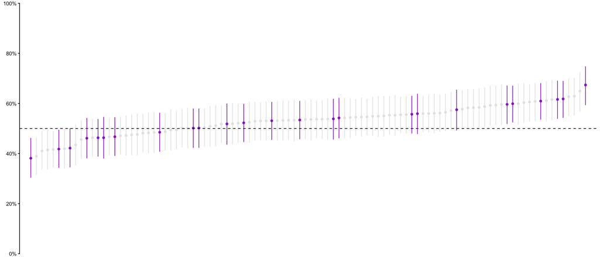

```r
# Plot core:

word_p <- word_posts |>
  mutate(class_red = if_else(word_class == 'Mim', 'mimetic', 'other'),
         class_red = factor(class_red, levels = c('other', 'mimetic'))) |>
  ggplot(aes(x = word, y = estimate, col = class_red)) +
  geom_point() +
  geom_segment(aes(y = lower_ci, yend = upper_ci)) +
  geom_hline(linetype = 'dashed', yintercept = 0.5)

# Axes and cosmetics:

word_p <- word_p +
  scale_color_manual(values = c('gray90', 'darkorchid3')) +
  scale_x_discrete(expand = c(0.02, 0.02)) +
  scale_y_continuous(limits = c(0, 1.0),
                     breaks = seq(0, 1, 0.2),
                     expand = c(0, 0),
                     labels = str_c(seq(0, 100, 20), '%')) +
  xlab(NULL) +
  ylab(NULL) +
  theme_classic() +
  theme(axis.line.x = element_blank(),
        axis.text.x = element_blank(),
        axis.ticks.x = element_blank(),
        legend.position = 'none')

# Show and save:

word_p
```

```r
ggsave(plot = word_p, filename = '../figures/png/word_posteriors_with_mimetics.png',
       width = 12, height = 5)
ggsave(plot = word_p, filename = '../figures/pdf/word_posteriors_with_mimetics.pdf',
       width = 12, height = 5)
```

Verb highlight:

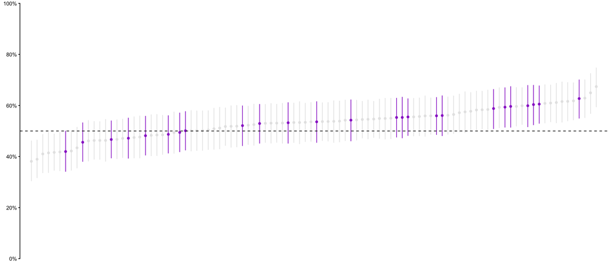

```r
# Plot core:

word_p <- word_posts |>
  mutate(class_red = if_else(word_class == 'Verb', 'verb', 'other'),
         class_red = factor(class_red, levels = c('other', 'verb'))) |>
  ggplot(aes(x = word, y = estimate, col = class_red)) +
  geom_point() +
  geom_segment(aes(y = lower_ci, yend = upper_ci)) +
  geom_hline(linetype = 'dashed', yintercept = 0.5)

# Axes and cosmetics:

word_p <- word_p +
  scale_color_manual(values = c('gray90', 'darkorchid3')) +
  scale_x_discrete(expand = c(0.02, 0.02)) +
  scale_y_continuous(limits = c(0, 1.0),
                     breaks = seq(0, 1, 0.2),
                     expand = c(0, 0),
                     labels = str_c(seq(0, 100, 20), '%')) +
  xlab(NULL) +
  ylab(NULL) +
  theme_classic() +
  theme(axis.line.x = element_blank(),
        axis.text.x = element_blank(),
        axis.ticks.x = element_blank(),
        legend.position = 'none')

# Show and save:

word_p
```

```r
ggsave(plot = word_p, filename = '../figures/png/word_posteriors_with_verbs.png',
       width = 12, height = 5)
ggsave(plot = word_p, filename = '../figures/pdf/word_posteriors_with_verbs.pdf',
       width = 12, height = 5)
```

Adjective highlight:

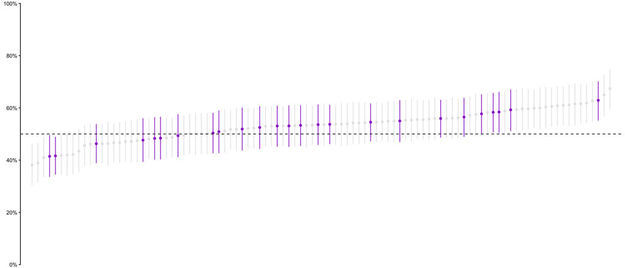

```r
# Plot core:

word_p <- word_posts |>
  mutate(class_red = if_else(word_class == 'Adj', 'adjective', 'other'),
         class_red = factor(class_red, levels = c('other', 'adjective'))) |>
  ggplot(aes(x = word, y = estimate, col = class_red)) +
  geom_point() +
  geom_segment(aes(y = lower_ci, yend = upper_ci)) +
  geom_hline(linetype = 'dashed', yintercept = 0.5)

# Axes and cosmetics:

word_p <- word_p +
  scale_color_manual(values = c('gray90', 'darkorchid3')) +
  scale_x_discrete(expand = c(0.02, 0.02)) +
  scale_y_continuous(limits = c(0, 1.0),
                     breaks = seq(0, 1, 0.2),
                     expand = c(0, 0),
                     labels = str_c(seq(0, 100, 20), '%')) +
  xlab(NULL) +
  ylab(NULL) +
  theme_classic() +
  theme(axis.line.x = element_blank(),
        axis.text.x = element_blank(),
        axis.ticks.x = element_blank(),
        legend.position = 'none')

# Show and save:

word_p
```

```r
ggsave(plot = word_p, filename = '../figures/png/word_posteriors_with_adjectives.png',
       width = 12, height = 5)
ggsave(plot = word_p, filename = '../figures/pdf/word_posteriors_with_adjectives.pdf',
       width = 12, height = 5)
```

Noun highlight:

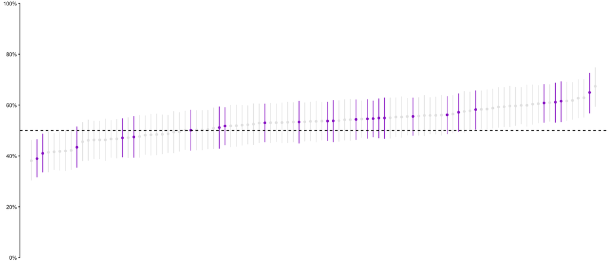

```r
# Plot core:

word_p <- word_posts |>
  mutate(class_red = if_else(word_class == 'Noun', 'noun', 'other'),
         class_red = factor(class_red, levels = c('other', 'noun'))) |>
  ggplot(aes(x = word, y = estimate, col = class_red)) +
  geom_point() +
  geom_segment(aes(y = lower_ci, yend = upper_ci)) +
  geom_hline(linetype = 'dashed', yintercept = 0.5)

# Axes and cosmetics:

word_p <- word_p +
  scale_color_manual(values = c('gray90', 'darkorchid3')) +
  scale_x_discrete(expand = c(0.02, 0.02)) +
  scale_y_continuous(limits = c(0, 1.0),
                     breaks = seq(0, 1, 0.2),
                     expand = c(0, 0),
                     labels = str_c(seq(0, 100, 20), '%')) +
  xlab(NULL) +
  ylab(NULL) +
  theme_classic() +
  theme(axis.line.x = element_blank(),
        axis.text.x = element_blank(),
        axis.ticks.x = element_blank(),
        legend.position = 'none')

# Show and save:

word_p
```

```r
ggsave(plot = word_p, filename = '../figures/png/word_posteriors_with_nouns.png',
       width = 12, height = 5)
ggsave(plot = word_p, filename = '../figures/pdf/word_posteriors_with_nouns.pdf',
       width = 12, height = 5)
```

## 4.8 Visualize posteriors of random effects

Kuleshova et al. (2026) discuss how there is more item variability than subject variability. If there is *any* signal in the words themselves, this should be the case here too. Let’s make a plot of this:

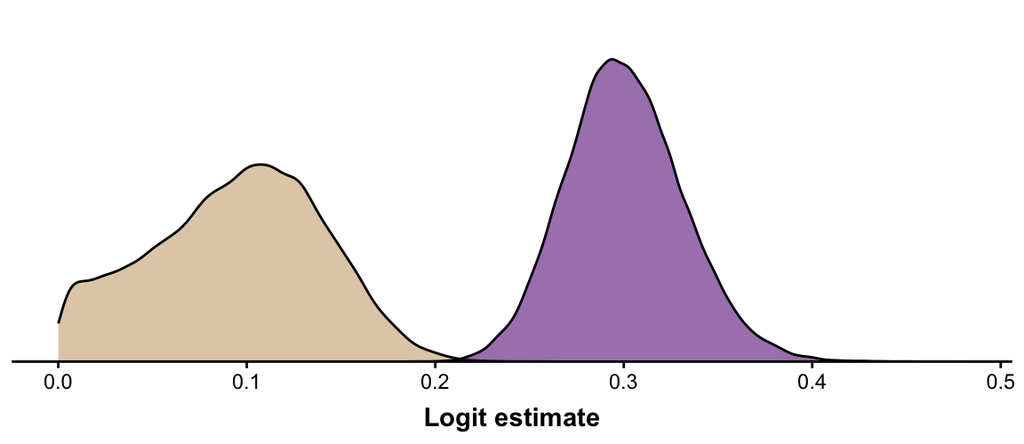

```r
# Plot core:

sd_p <- both_posts |>
  pivot_longer(cols = sd_unique_id__Intercept:sd_word__Intercept,
               names_to = 'sd', values_to = 'estimate') |>
  mutate(sd = if_else(sd == 'sd_unique_id__Intercept',
                      'participant', 'word')) |>
  ggplot(aes(x = estimate)) +
  geom_density(aes(fill = sd), alpha = 0.6)

# Plot core:

sd_p <- sd_p +
  scale_fill_manual(values = c('burlywood3', 'darkorchid4')) +
  scale_y_continuous(expand = c(0, 0),
                     limits = c(0, 15)) +
  xlab('Logit estimate') +
  ylab(NULL) +
  theme_classic() +
  theme(axis.title.x = element_text(face = 'bold', margin = margin(t = 6))) +
  theme(axis.line.y = element_blank(),
        axis.ticks.y = element_blank(),
        axis.text.y = element_blank(),
        legend.position = 'none')

sd_p
```

```r
ggsave('../figures/pdf/experiment_sd_comparisons.pdf',
       width = 6, height = 2.8)
ggsave('../figures/png/experiment_sd_comparisons.png',
       width = 6, height = 2.8)
```

This completes this analysis.